# Target Marketing

## Data Preparation

Dynamic fuction to install and load the package

```r
#Function to check library is there in current machine or not, If not it will install and load in Environment
usePackage <- function(p)
{
  if (!is.element(p, installed.packages()[,1]))
    install.packages(p, dep = TRUE)
  require(p, character.only = TRUE)
}
```

Loading the required packages

```r
#List of library to be loaded in environment
usePackage("readxl")
usePackage("knitr")
usePackage("ggplot2")
usePackage("lubridate")
usePackage("ROSE")
usePackage("usdm")
usePackage("DMwR")
usePackage("randomForest")
usePackage("vegan")
usePackage("arm")
```

```
arm (Version 1.9-3, built: 2016-11-21)

Working directory is C:/Users/mohamed.noordeen/Desktop/Mohamed_Noordeen_Alaudeen_Batch25_RCode
```

```r
usePackage("car")
usePackage("MASS")
usePackage("caret")
usePackage("ROCR")
usePackage("ggplot2")
usePackage("e1071")
usePackage("infotheo")
usePackage("C50")
usePackage("rpart")
usePackage("ada")
usePackage("h2o")
```

[output not shown]

```r
usePackage("xgboost")
```

Setting the directory

```r
#Setting the directory
(Working.Directory <- getwd())
```

```
[1] "C:/Users/mohamed.noordeen/Desktop/Mohamed_Noordeen_Alaudeen_Batch25_RCode"
```

```r
if (!is.null(Working.Directory))
  setwd(Working.Directory)
```

Loading the data

```r
knitr::opts_knit$set(root.dir = 'C:/Users/mohamed.noordeen/Desktop/TargetMarketing')
Data.Marketing <- read_excel(path = "Target Marketing and cross selling - Data.xls",col_names = c("Branch.ID", "Customer.ID", "Bill.To", "Customer.Type", "Customer.Name", "Address", "City", "State", "Zip.Code",
        "Zip.5", "Area.1", "Area.2", "Contact", "Setup.Date", "Last.Service.Date", "Ticket.Number",
        "Current.Email", "Rev.Code", "Job.Code", "Call.Date", "Complete.Date", "Ticket.Revenue",
        "Year.Month", "Year", "Week.Ending.Date", "Call.Time", "Schedule.Date", "Schedule.Time",
        "Dispatch.Date", "Dispatch.Time", "Complete.Time"),sheet = 1, skip = 1)
```

## Data Discovery

Learning about the data

```r
#Finding the incompleteness in data
nrows <- nrow(Data.Marketing)
ncomplete <- sum(complete.cases(Data.Marketing))
ncomplete
```

```
[1] 3802
```

```r
str(Data.Marketing)
```

```
Classes tbl_df, tbl and 'data.frame':   5284 obs. of  31 variables:
 $ Branch.ID        : chr  "B0047" "B0047" "B0047" "B0047" ...
 $ Customer.ID      : chr  "C000637" "C000637" "C000637" "C000637" ...
 $ Bill.To          : num  0 0 0 0 0 ...
 $ Customer.Type    : chr  "CustType02" "CustType02" "CustType02" "CustType02" ...
 $ Customer.Name    : chr  "ABC0011" "ABC0011" "ABC0011" "ABC0011" ...
 $ Address          : chr  "857 Address" "857 Address" "857 Address" "857 Address" ...
 $ City             : chr  "ALEXANDRIA" "ALEXANDRIA" "ALEXANDRIA" "ALEXANDRIA" ...
 $ State            : chr  "VA" "VA" "VA" "VA" ...
 $ Zip.Code         : num  2.23e+08 2.23e+08 2.23e+08 2.23e+08 2.23e+08 ...
 $ Zip.5            : num  22310 22310 22310 22310 22310 ...
 $ Area.1           : num  703 703 703 703 703 913 401 985 504 504 ...
 $ Area.2           : num  910 910 910 910 910 0 401 985 0 504 ...
 $ Contact          : chr  "#2TT AMANDA" "#2TT AMANDA" "#2TT AMANDA" "#2TT AMANDA" ...
 $ Setup.Date       : POSIXct, format: "2011-07-17" "2011-07-17" "2011-07-17" "2011-07-17" ...
```

[output cut: 17 more lines]

Percentage of the data completness

```r
ncomplete/nrows
```

```
[1] 0.7195307
```

```r
rm(ncomplete,nrows)
```

Number of NA values

```r
sum(is.na(Data.Marketing))
```

```
[1] 1502
```

Vewing Columnames

```r
colnames(Data.Marketing)
```

```
 [1] "Branch.ID"         "Customer.ID"       "Bill.To"           "Customer.Type"     "Customer.Name"
 [6] "Address"           "City"              "State"             "Zip.Code"          "Zip.5"
[11] "Area.1"            "Area.2"            "Contact"           "Setup.Date"        "Last.Service.Date"
[16] "Ticket.Number"     "Current.Email"     "Rev.Code"          "Job.Code"          "Call.Date"
[21] "Complete.Date"     "Ticket.Revenue"    "Year.Month"        "Year"              "Week.Ending.Date"
[26] "Call.Time"         "Schedule.Date"     "Schedule.Time"     "Dispatch.Date"     "Dispatch.Time"
[31] "Complete.Time"
```

Number of Na’s in each column

```r
apply(Data.Marketing,2,function(x){sum(is.na(x))})
```

```
        Branch.ID       Customer.ID           Bill.To     Customer.Type     Customer.Name           Address
                0                 0                 0                 0               115                 0
             City             State          Zip.Code             Zip.5            Area.1            Area.2
                0                 0                 0                 0                 0                 0
          Contact        Setup.Date Last.Service.Date     Ticket.Number     Current.Email          Rev.Code
                0                 0                 0                 0              1387                 0
         Job.Code         Call.Date     Complete.Date    Ticket.Revenue        Year.Month              Year
                0                 0                 0                 0                 0                 0
 Week.Ending.Date         Call.Time     Schedule.Date     Schedule.Time     Dispatch.Date     Dispatch.Time
                0                 0                 0                 0                 0                 0
    Complete.Time
                0
```

Checking the structure of the data

```r
str(Data.Marketing)
```

```
Classes tbl_df, tbl and 'data.frame':   5284 obs. of  31 variables:
 $ Branch.ID        : chr  "B0047" "B0047" "B0047" "B0047" ...
 $ Customer.ID      : chr  "C000637" "C000637" "C000637" "C000637" ...
 $ Bill.To          : num  0 0 0 0 0 ...
 $ Customer.Type    : chr  "CustType02" "CustType02" "CustType02" "CustType02" ...
 $ Customer.Name    : chr  "ABC0011" "ABC0011" "ABC0011" "ABC0011" ...
 $ Address          : chr  "857 Address" "857 Address" "857 Address" "857 Address" ...
 $ City             : chr  "ALEXANDRIA" "ALEXANDRIA" "ALEXANDRIA" "ALEXANDRIA" ...
 $ State            : chr  "VA" "VA" "VA" "VA" ...
 $ Zip.Code         : num  2.23e+08 2.23e+08 2.23e+08 2.23e+08 2.23e+08 ...
 $ Zip.5            : num  22310 22310 22310 22310 22310 ...
 $ Area.1           : num  703 703 703 703 703 913 401 985 504 504 ...
 $ Area.2           : num  910 910 910 910 910 0 401 985 0 504 ...
 $ Contact          : chr  "#2TT AMANDA" "#2TT AMANDA" "#2TT AMANDA" "#2TT AMANDA" ...
 $ Setup.Date       : POSIXct, format: "2011-07-17" "2011-07-17" "2011-07-17" "2011-07-17" ...
```

[output cut: 17 more lines]

Checking unique number of data in each column

```r
apply(Data.Marketing,2,function(x){length(unique(x))})
```

```
        Branch.ID       Customer.ID           Bill.To     Customer.Type     Customer.Name           Address
               47              1058               169                 3                14              1059
             City             State          Zip.Code             Zip.5            Area.1            Area.2
              497                28              1059               845               128               126
          Contact        Setup.Date Last.Service.Date     Ticket.Number     Current.Email          Rev.Code
              827               637               494              5280               780                 3
         Job.Code         Call.Date     Complete.Date    Ticket.Revenue        Year.Month              Year
               34              1105              1113              3103                38                 4
 Week.Ending.Date         Call.Time     Schedule.Date     Schedule.Time     Dispatch.Date     Dispatch.Time
              163              1022              1109               723              1109               925
    Complete.Time
              957
```

Checking the unique number of rows

```r
nrow(unique(Data.Marketing))
```

```
[1] 5284
```

Other way of finding any duplication in data

```r
Data.Marketing[duplicated(Data.Marketing), ]
```

| Branch.ID | Customer.ID | Bill.To | Customer.Type | Customer.Name | Address | City | State | Zip.Code | Zip.5 | Area.1 | Area.2 | Contact | Setup.Date | Last.Service.Date | Ticket.Number | Current.Email | Rev.Code | Job.Code | Call.Date | Complete.Date | Ticket.Revenue | Year.Month | Year | Week.Ending.Date | Call.Time | Schedule.Date | Schedule.Time | Dispatch.Date | Dispatch.Time | … |
| --- | --- | --- | --- | --- | --- | --- | --- | --- | --- | --- | --- | --- | --- | --- | --- | --- | --- | --- | --- | --- | --- | --- | --- | --- | --- | --- | --- | --- | --- | --- |

Viewing the dimension of the data

```r
dim(Data.Marketing)
```

```
[1] 5284   31
```

Summarizing the data

```r
summary(Data.Marketing)
```

```
  Branch.ID         Customer.ID           Bill.To       Customer.Type      Customer.Name        Address
 Length:5284        Length:5284        Min.   :     0   Length:5284        Length:5284        Length:5284
 Class :character   Class :character   1st Qu.:     0   Class :character   Class :character   Class :character
 Mode  :character   Mode  :character   Median :     0   Mode  :character   Mode  :character   Mode  :character
                                       Mean   : 36899
                                       3rd Qu.:     0
                                       Max.   :406391
     City              State              Zip.Code             Zip.5           Area.1        Area.2
 Length:5284        Length:5284        Min.   :     1863   Min.   : 1420   Min.   :201   Min.   :  0.0
 Class :character   Class :character   1st Qu.:194014575   1st Qu.:20002   1st Qu.:314   1st Qu.:  0.0
 Mode  :character   Mode  :character   Median :336125325   Median :34747   Median :612   Median :  0.0
                                       Mean   :419807646   Mean   :42944   Mean   :570   Mean   :236.4
                                       3rd Qu.:631302207   3rd Qu.:63138   3rd Qu.:770   3rd Qu.:512.0
                                       Max.   :985165850   Max.   :98516   Max.   :985   Max.   :985.0
   Contact            Setup.Date                  Last.Service.Date             Ticket.Number
 Length:5284        Min.   :2008-09-30 00:00:00   Min.   :2011-05-20 00:00:00   Min.   :  299638
 Class :character   1st Qu.:2011-05-19 18:00:00   1st Qu.:2013-02-06 00:00:00   1st Qu.:16459757
 Mode  :character   Median :2011-11-04 00:00:00   Median :2013-08-13 00:00:00   Median :16816221
                    Mean   :2012-01-21 07:04:02   Mean   :2013-06-09 18:57:46   Mean   :16627500
                    3rd Qu.:2012-08-18 00:00:00   3rd Qu.:2013-12-04 00:00:00   3rd Qu.:17180467
                    Max.   :2014-02-02 00:00:00   Max.   :2014-02-05 00:00:00   Max.   :17731621
 Current.Email         Rev.Code        Job.Code        Call.Date                   Complete.Date
 Length:5284        Min.   :1.000   Min.   : 0.000   Min.   :2010-12-22 00:00:00   Min.   :2010-12-22 00:00:00
 Class :character   1st Qu.:1.000   1st Qu.: 2.000   1st Qu.:2011-12-01 00:00:00   1st Qu.:2011-12-02 18:00:00
 Mode  :character   Median :2.000   Median : 5.000   Median :2012-08-28 00:00:00   Median :2012-08-29 12:00:00
                    Mean   :1.998   Mean   : 9.434   Mean   :2012-08-18 15:04:13   Mean   :2012-08-19 13:29:06
                    3rd Qu.:3.000   3rd Qu.:14.000   3rd Qu.:2013-05-11 00:00:00   3rd Qu.:2013-05-13 00:00:00
                    Max.   :3.000   Max.   :50.000   Max.   :2014-02-04 00:00:00   Max.   :2014-02-04 00:00:00
 Ticket.Revenue       Year.Month          Year      Week.Ending.Date                Call.Time
 Min.   :   50.87   Min.   :201101   Min.   :2011   Min.   :2010-12-28 00:00:00   Min.   :   0
 1st Qu.:  200.00   1st Qu.:201112   1st Qu.:2011   1st Qu.:2011-12-06 00:00:00   1st Qu.: 953
 Median :  299.90   Median :201209   Median :2012   Median :2012-09-04 00:00:00   Median :1225
 Mean   :  449.86   Mean   :201224   Mean   :2012   Mean   :2012-08-22 12:28:04   Mean   :1264
 3rd Qu.:  477.67   3rd Qu.:201305   3rd Qu.:2013   3rd Qu.:2013-05-14 00:00:00   3rd Qu.:1528
 Max.   :11391.22   Max.   :201402   Max.   :2014   Max.   :2014-02-04 00:00:00   Max.   :2357
 Schedule.Date                 Schedule.Time  Dispatch.Date                 Dispatch.Time  Complete.Time
 Min.   :2010-12-22 00:00:00   Min.   :   0   Min.   :2000-01-01 00:00:00   Min.   :   0   Min.   :   0
 1st Qu.:2011-12-02 00:00:00   1st Qu.: 802   1st Qu.:2011-12-01 18:00:00   1st Qu.: 933   1st Qu.:1207
 Median :2012-08-30 00:00:00   Median :1028   Median :2012-08-29 00:00:00   Median :1214   Median :1448
 Mean   :2012-08-20 01:21:29   Mean   :1102   Mean   :2012-08-14 10:18:53   Mean   :1232   Mean   :1458
 3rd Qu.:2013-05-13 00:00:00   3rd Qu.:1400   3rd Qu.:2013-05-13 00:00:00   3rd Qu.:1500   3rd Qu.:1722
 Max.   :2020-12-31 00:00:00   Max.   :2359   Max.   :2014-02-04 00:00:00   Max.   :2359   Max.   :2359
```

Viewing column names and class of data

```r
attributes(Data.Marketing)
```

```
$names
 [1] "Branch.ID"         "Customer.ID"       "Bill.To"           "Customer.Type"     "Customer.Name"
 [6] "Address"           "City"              "State"             "Zip.Code"          "Zip.5"
[11] "Area.1"            "Area.2"            "Contact"           "Setup.Date"        "Last.Service.Date"
[16] "Ticket.Number"     "Current.Email"     "Rev.Code"          "Job.Code"          "Call.Date"
[21] "Complete.Date"     "Ticket.Revenue"    "Year.Month"        "Year"              "Week.Ending.Date"
[26] "Call.Time"         "Schedule.Date"     "Schedule.Time"     "Dispatch.Date"     "Dispatch.Time"
[31] "Complete.Time"

$class
[1] "tbl_df"     "tbl"        "data.frame"

$row.names
   [1]    1    2    3    4    5    6    7    8    9   10   11   12   13   14   15   16   17   18   19   20   21
  [22]   22   23   24   25   26   27   28   29   30   31   32   33   34   35   36   37   38   39   40   41   42
```

[output cut: 47 more lines]

Veiwing first 6 dataframe

```r
head(Data.Marketing)
```

| Branch.ID | Customer.ID | Bill.To | Customer.Type | Customer.Name | Address | City | State | Zip.Code | Zip.5 | Area.1 | Area.2 | Contact | Setup.Date | Last.Service.Date | Ticket.Number | Current.Email | Rev.Code | Job.Code | Call.Date | Complete.Date | Ticket.Revenue | Year.Month | Year | Week.Ending.Date | Call.Time | Schedule.Date | Schedule.Time | Dispatch.Date | Dispatch.Time | … |
| --- | --- | --- | --- | --- | --- | --- | --- | --- | --- | --- | --- | --- | --- | --- | --- | --- | --- | --- | --- | --- | --- | --- | --- | --- | --- | --- | --- | --- | --- | --- |
| B0047 | C000637 | 0 | CustType02 | ABC0011 | 857 Address | ALEXANDRIA | VA | 223102436 | 22310 | 703 | 910 | #2TT AMANDA | 2011-07-17 | 2012-08-26 | 16895635 | XYZ0022@MAIL.COM | 3 | 13 | 2012-08-26 | 2012-08-26 | 306.19 | 201209 | 2012 | 2012-08-28 | 709 | 2012-08-26 | 800 | 2012-08-26 | 1106 | … |
| B0047 | C000637 | 0 | CustType02 | ABC0011 | 857 Address | ALEXANDRIA | VA | 223102436 | 22310 | 703 | 910 | #2TT AMANDA | 2011-07-17 | 2012-08-26 | 16786733 | XYZ0022@MAIL.COM | 3 | 13 | 2012-06-03 | 2012-06-04 | 317.11 | 201206 | 2012 | 2012-06-05 | 2033 | 2012-06-04 | 900 | 2012-06-04 | 1012 | … |
| B0047 | C000637 | 0 | CustType02 | ABC0011 | 857 Address | ALEXANDRIA | VA | 223102436 | 22310 | 703 | 910 | #2TT AMANDA | 2011-07-17 | 2012-08-26 | 16585679 | XYZ0022@MAIL.COM | 3 | 29 | 2012-01-03 | 2012-01-05 | 155.15 | 201201 | 2012 | 2012-01-10 | 1717 | 2012-01-05 | 801 | 2012-01-05 | 725 | … |
| B0047 | C000637 | 0 | CustType02 | ABC0011 | 857 Address | ALEXANDRIA | VA | 223102436 | 22310 | 703 | 910 | #2TT AMANDA | 2011-07-17 | 2012-08-26 | 16520466 | XYZ0022@MAIL.COM | 3 | 0 | 2011-11-19 | 2011-11-19 | 363.00 | 201112 | 2011 | 2011-11-22 | 1303 | 2011-11-19 | 1304 | 2011-11-19 | 1331 | … |
| B0047 | C000637 | 0 | CustType02 | ABC0011 | 857 Address | ALEXANDRIA | VA | 223102436 | 22310 | 703 | 910 | #2TT AMANDA | 2011-07-17 | 2012-08-26 | 16346652 | XYZ0022@MAIL.COM | 3 | 13 | 2011-07-17 | 2011-07-17 | 526.29 | 201107 | 2011 | 2011-07-19 | 1320 | 2011-07-17 | 1332 | 2011-07-17 | 1339 | … |
| B0046 | C000164 | 225243 | CustType02 | ABC0069 | 916 Address | SHAWNEE | KS | 662034621 | 66203 | 913 | 0 | VINCENT CL# WOW | 2011-07-13 | 2013-08-06 | 16371263 | NA | 3 | 9 | 2011-09-06 | 2011-09-07 | 157.46 | 201109 | 2011 | 2011-09-13 | 1621 | 2011-09-07 | 802 | 2011-09-07 | 748 | … |

## Feature Engineering

Data Cleansing Preprocessing

Removing month from year Column

```r
Data.Marketing$Month = as.numeric(substr(Data.Marketing$Year.Month,5,6))
```

Function to append data and Time

```r
appendDateTime <- function(Data.Marketing){

# Converting the Dispatch Time column into the right format HH:MM
Data.Marketing$Dispatch.Time <- substr(as.POSIXct(sprintf("%04.0f", as.numeric(Data.Marketing$Dispatch.Time)),    format='%H%M'), 12, 16)
# Sample Converting 1240 -> 12:40

# Converting the Complete Time column HHMM into the right format HH:MM
Data.Marketing$Complete.Time <- substr(as.POSIXct(sprintf("%04.0f", as.numeric(Data.Marketing$Complete.Time)), format='%H%M'), 12, 16)
# Sample Converting 040 -> 00:40

# Converting the Schedule Time column HHMM into the right format HH:MM
Data.Marketing$Schedule.Time <- substr(as.POSIXct(sprintf("%04.0f", as.numeric(Data.Marketing$Schedule.Time)), format='%H%M'), 12, 16)
# Sample Converting 040 -> 00:40

# Converting the Call Time column HHMM into the right format HH:MM
Data.Marketing$Call.Time <- substr(as.POSIXct(sprintf("%04.0f", as.numeric(Data.Marketing$Call.Time)), format='%H%M'), 12, 16)
# Sample Converting 040 -> 00:40

# Appending Complete Date and Time
Data.Marketing$Complete.Date.Time <- as.POSIXct(with(Data.Marketing, paste(Complete.Date, Complete.Time), format="%m/%d/%Y %H:%M"))
# Sample Appending 6/4/2012 and 12:40 -> 6/4/2012 12:40 IST

# Appending Dispatch Date and Time
Data.Marketing$Dispatch.Date.Time <- as.POSIXct(with(Data.Marketing, paste(Dispatch.Date, Dispatch.Time), format="%m/%d/%Y %H:%M"))
# Sample Appending 6/4/2012 and 12:40 -> 6/4/2012 12:40 IST

# Appending Schedule Date and Time
Data.Marketing$Schedule.Date.Time <- as.POSIXct(with(Data.Marketing, paste(Schedule.Date, Schedule.Time), format="%m/%d/%Y %H:%M"))
# Sample Appending 6/4/2012 and 12:40 -> 6/4/2012 12:40 IST

# Data.Marketing Call Date and Time
Data.Marketing$Call.Date.Time <- as.POSIXct(with(Data.Marketing, paste(Call.Date, Call.Time), format="%m/%d/%Y %H:%M"))
# Sample Appending 6/4/2012 and 12:40 -> 6/4/2012 12:40 IST

# Formating Proper Setup Date
Data.Marketing$Setup.Date <- as.POSIXct(with(Data.Marketing, paste(Setup.Date), format="%m/%d/%Y"))

return (Data.Marketing)

}
Data.Marketing <- appendDateTime(Data.Marketing)
```

Remove unwanted date variables

```r
rmDateTimeVaribles <- c("Customer.Name","Address","Contact",
                        "Last.Service.Date","Current.Email","Call.Date","Complete.Date","Call.Time","Schedule.Date",
                        "Schedule.Time","Ticket.Number","Dispatch.Date","Dispatch.Time","Complete.Time","Year.Month")
Required.Variables <- setdiff(names(Data.Marketing),rmDateTimeVaribles)
Required.Variables
```

```
 [1] "Branch.ID"          "Customer.ID"        "Bill.To"            "Customer.Type"      "City"
 [6] "State"              "Zip.Code"           "Zip.5"              "Area.1"             "Area.2"
[11] "Setup.Date"         "Rev.Code"           "Job.Code"           "Ticket.Revenue"     "Year"
[16] "Week.Ending.Date"   "Month"              "Complete.Date.Time" "Dispatch.Date.Time" "Schedule.Date.Time"
[21] "Call.Date.Time"
```

```r
Data.Marketing.Clean <- Data.Marketing[,Required.Variables]
#Remove unwanted variables
rm(rmDateTimeVaribles,Required.Variables)
```

Sorting the data based on customerID’s and their call date

```r
Data.Marketing.Clean <- Data.Marketing.Clean[with(Data.Marketing.Clean,order(Customer.ID, as.Date(Call.Date.Time, format="%m/%d/%Y  %H:%M"))),]
```

Adding the visit number for each customer

```r
addVisitNumber <- function(Data.Marketing.Clean){

  # Writing a script to add a column with label indicating visit number of each customer
  visit = 1
  Data.Marketing.Clean$visit = 1
  for(i in 1:nrow(Data.Marketing.Clean)){

    if(i==nrow(Data.Marketing.Clean)){
        Data.Marketing.Clean$visit[i] = visit
    }
    else{
      if(Data.Marketing.Clean$Customer.ID[i]!=Data.Marketing.Clean$Customer.ID[i+1]){
        Data.Marketing.Clean$visit[i] = visit
        visit = 1
      }
      else{
        Data.Marketing.Clean$visit[i] = visit
        visit <- visit + 1
      }
    }
  }

  return (Data.Marketing.Clean)
}
Data.Marketing.Clean <- addVisitNumber(Data.Marketing.Clean)
```

Finding Customer Callback days

```r
# Differencing the call date to find time taken for customer to call back
Data.Marketing.Clean <-  transform(Data.Marketing.Clean, Customer.Call.Back=unlist(tapply(Call.Date.Time, Customer.ID, function(x) c(0, diff(as.Date(x, format="%m/%d/%Y %H:%M"))))))
```

Finding Customer Ticket Transaction

```r
# Differencing the ticket revenue  to find hiked or offered
Data.Marketing.Clean <-  transform(Data.Marketing.Clean, Customer.Ticket.status=unlist(tapply(Ticket.Revenue, Customer.ID, function(x) c(0, diff((x))))))
Data.Marketing.Clean <-  transform(Data.Marketing.Clean, Customer.Ticket.pricing=unlist(tapply(Customer.Ticket.status, Customer.ID, function(x) c(0, diff((x))))))
Data.Marketing.Clean <-  transform(Data.Marketing.Clean, Customer.Ticket.pricing.old=unlist(tapply(Customer.Ticket.pricing, Customer.ID, function(x) c(0, diff((x))))))
```

Differencing the Week.Ending.Date to find time taken for customer to call back

```r
Data.Marketing.Clean <-  transform(Data.Marketing.Clean, Customer.Week.Back=unlist(tapply(Week.Ending.Date, Customer.ID, function(x) c(0, diff(as.Date(x, format="%m/%d/%Y %H:%M"))))))
```

Differencing setup date and call date

```r
Data.Marketing.Clean$Days.interval.setup = as.numeric( round(difftime(Data.Marketing.Clean$Call.Date.Time,Data.Marketing.Clean$Setup.Date, units = "days"),0)) # days
```

Differencing calldate and schedule date

```r
Data.Marketing.Clean$Days.Scheduled.After.Call =  as.numeric(   round(difftime(Data.Marketing.Clean$Schedule.Date.Time,Data.Marketing.Clean$Call.Date.Time, units = "days"),0)) # days
```

Differencing Schedule and Dispatch date

```r
Data.Marketing.Clean$Days.Dispatched.After.Schedule =   as.numeric( round(difftime(Data.Marketing.Clean$Dispatch.Date.Time,Data.Marketing.Clean$Schedule.Date.Time, units = "days"),0)) # days
```

Differencing Dispatch and Complete date

```r
Data.Marketing.Clean$Days.Completed.After.Dispatched =   as.numeric( round(difftime(Data.Marketing.Clean$Complete.Date.Time,Data.Marketing.Clean$Dispatch.Date.Time, units = "days"),0)) # days
```

Differencing call and Complete date

```r
Data.Marketing.Clean$Days.Completed.After.Call =   as.numeric( round(difftime(Data.Marketing.Clean$Complete.Date.Time,Data.Marketing.Clean$Call.Date.Time, units = "days"),0)) # days
```

```r
Data.Marketing.Clean$Quarter = quarter(Data.Marketing.Clean$Week.Ending.Date)
```

Diferencing weekdate and setup date

```r
Data.Marketing.Clean$Days.WeekFiscal.setup =   as.numeric( round(difftime(Data.Marketing.Clean$Week.Ending.Date,Data.Marketing.Clean$Setup.Date, units = "days"),0)) # days
```

Diferencing weekdate and call date

```r
Data.Marketing.Clean$Days.WeekFiscal.call =   as.numeric( round(difftime(Data.Marketing.Clean$Week.Ending.Date,Data.Marketing.Clean$Call.Date.Time, units = "days"),0)) # days
```

Differencing weekdate and schedule date

```r
Data.Marketing.Clean$Days.WeekFiscal.Schedule =   as.numeric( round(difftime(Data.Marketing.Clean$Week.Ending.Date,Data.Marketing.Clean$Schedule.Date.Time, units = "days"),0)) # days
```

Differencing weekdate and dispatch date

```r
Data.Marketing.Clean$Days.WeekFiscal.Dispatch =   as.numeric( round(difftime(Data.Marketing.Clean$Week.Ending.Date,Data.Marketing.Clean$Dispatch.Date.Time, units = "days"),0)) # days
```

Differencing weekdate and Complete date

```r
Data.Marketing.Clean$Days.WeekFiscal.Complete =   as.numeric( round(difftime(Data.Marketing.Clean$Week.Ending.Date,Data.Marketing.Clean$Complete.Date.Time, units = "days"),0)) # days
```

Finding the threshold

```r
findCallBackThresholdForEachCustomerType <- function(targetData){

  # Every last row of each customer is a test data
  # Writing a script to add a column with label indicating with train and test
  targetData$label = "train"
  for(i in 1:nrow(targetData)){
    if(i==nrow(targetData)){
      targetData$label[i] = "test"
    }
    else{
      if(targetData$Customer.ID[i]!=targetData$Customer.ID[i+1]){
        targetData$label[i] = "test"
      }
    }
  }

  # Rechecking the structure of the data
  str(targetData)


  #Separating the dataframe with train and test
  DiffCalldateTargetdataTrain <- targetData[which(targetData$label=="train"),]
  DiffCalldateTargetdataTest <- targetData[which(targetData$label=="test"),]

  # Finding the threshold of each customertype
  # Mean of number of days customer will calling back
  # Mean is calculated on the train data only
  DiffCalldateTargetdata.mean.by.CustomerType <- round(by( DiffCalldateTargetdataTrain$Customer.Call.Back,   DiffCalldateTargetdataTrain$Customer.Type, mean),0)

  return (DiffCalldateTargetdata.mean.by.CustomerType)
}
thresholdOfCustomerType <- findCallBackThresholdForEachCustomerType(Data.Marketing.Clean)
```

```
'data.frame':   5284 obs. of  39 variables:
 $ Branch.ID                      : chr  "B0033" "B0033" "B0033" "B0033" ...
 $ Customer.ID                    : chr  "C000001" "C000001" "C000001" "C000001" ...
 $ Bill.To                        : num  808 808 808 808 808 ...
 $ Customer.Type                  : chr  "CustType03" "CustType03" "CustType03" "CustType03" ...
 $ City                           : chr  "BALTIMORE" "BALTIMORE" "BALTIMORE" "BALTIMORE" ...
 $ State                          : chr  "MD" "MD" "MD" "MD" ...
 $ Zip.Code                       : num  2.12e+08 2.12e+08 2.12e+08 2.12e+08 2.12e+08 ...
 $ Zip.5                          : num  21215 21215 21215 21215 21215 ...
 $ Area.1                         : num  410 410 410 410 410 410 410 410 410 410 ...
 $ Area.2                         : num  0 0 0 0 0 0 0 0 0 0 ...
 $ Setup.Date                     : POSIXct, format: "2012-07-16" "2012-07-16" "2012-07-16" "2012-07-16" ...
 $ Rev.Code                       : num  1 3 3 3 3 3 1 3 3 3 ...
 $ Job.Code                       : num  1 29 29 29 5 29 1 34 34 30 ...
 $ Ticket.Revenue                 : num  99 122 265 124 350 ...
```

[output cut: 25 more lines]

```r
thresholdOfCustomerType
```

```
DiffCalldateTargetdataTrain$Customer.Type: CustType01
[1] 112
------------------------------------------------------------------------------------
DiffCalldateTargetdataTrain$Customer.Type: CustType02
[1] 103
------------------------------------------------------------------------------------
DiffCalldateTargetdataTrain$Customer.Type: CustType03
[1] 87
```

Adding threshold as a column

```r
Data.Marketing.Clean$threshold_churn <- ifelse(Data.Marketing.Clean$Customer.Type=="CustType01",thresholdOfCustomerType["CustType01"],ifelse(Data.Marketing.Clean$Customer.Type=="CustType02",thresholdOfCustomerType["CustType02"],thresholdOfCustomerType["CustType03"]))
```

Differencing Threshold and CallBack

```r
Data.Marketing.Clean$Callback.Threshold.Diff <- Data.Marketing.Clean$threshold_churn - Data.Marketing.Clean$Customer.Call.Back
```

Making the data in column zero if it is negative

```r
Data.Marketing.Clean <-within(Data.Marketing.Clean, Customer.Week.Back<-Customer.Week.Back*(Customer.Week.Back>0))
Data.Marketing.Clean <- within(Data.Marketing.Clean, Days.interval.setup<-Days.interval.setup*(Days.interval.setup>0))
Data.Marketing.Clean <- within(Data.Marketing.Clean, Days.Scheduled.After.Call <-Days.Scheduled.After.Call*(Days.Scheduled.After.Call>0))
Data.Marketing.Clean <- within(Data.Marketing.Clean, Days.Dispatched.After.Schedule <-Days.Dispatched.After.Schedule*(Days.Dispatched.After.Schedule>0))
Data.Marketing.Clean <- within(Data.Marketing.Clean, Days.Dispatched.After.Schedule <-Days.Dispatched.After.Schedule*(Days.Dispatched.After.Schedule>0))
Data.Marketing.Clean <- within(Data.Marketing.Clean, Days.Completed.After.Dispatched <-Days.Completed.After.Dispatched*(Days.Completed.After.Dispatched>0))
Data.Marketing.Clean <- within(Data.Marketing.Clean, Days.Completed.After.Call <-Days.Completed.After.Call*(Days.Completed.After.Call>0))
Data.Marketing.Clean <- within(Data.Marketing.Clean, Days.WeekFiscal.setup <-Days.WeekFiscal.setup*(Days.WeekFiscal.setup>0))
Data.Marketing.Clean <- within(Data.Marketing.Clean, Days.WeekFiscal.call <-Days.WeekFiscal.call*(Days.WeekFiscal.call>0))
Data.Marketing.Clean <- within(Data.Marketing.Clean, Days.WeekFiscal.Schedule <-Days.WeekFiscal.Schedule*(Days.WeekFiscal.Schedule>0))
Data.Marketing.Clean <- within(Data.Marketing.Clean, Days.WeekFiscal.Dispatch <-Days.WeekFiscal.Dispatch*(Days.WeekFiscal.Dispatch>0))
Data.Marketing.Clean <- within(Data.Marketing.Clean, Days.WeekFiscal.Complete <-Days.WeekFiscal.Complete*(Days.WeekFiscal.Complete>0))
Data.Marketing.Clean <- within(Data.Marketing.Clean, Callback.Threshold.Diff <-Callback.Threshold.Diff*(Callback.Threshold.Diff>0))
```

Setting the churn data column based on threshold

```r
Data.Marketing.Clean$churn <- ifelse(Data.Marketing.Clean$Customer.Call.Back>=Data.Marketing.Clean$threshold_churn,1,0)
```

Likelihood to function to mask the data

```r
likelihood <- function(x){
  a<- round(sum(x)/length(x),1)
}
```

Checking the past ticket pricing for customer

```r
compareLastPricingWithCurrent <- function(targetData){

  #orderig the data based on customerid and call date
  targetData <- targetData[with(targetData,order(Customer.ID, as.Date(Call.Date.Time,format="%m/%d/%Y  %H:%M"))),]

  # Every last row of each customer is a test data
  customer = 1
  targetData$tickeket.hike = "0"
  for(i in 1:nrow(targetData)){

    if(customer < 3){
      targetData$tickeket.hike[i] = 0
      customer = customer + 1
    }
    else{
      if(i==nrow(targetData)){
        if(targetData$Ticket.Revenue[i-1]>targetData$Ticket.Revenue[i-2]){
            targetData$tickeket.hike[i] = 1
            }
      }
      else{
        if(targetData$Customer.ID[i]==targetData$Customer.ID[i+1]){
          if(targetData$Ticket.Revenue[i-1]>targetData$Ticket.Revenue[i-2]){
            targetData$tickeket.hike[i] = 1
            }
        }
        else{
          if(targetData$Ticket.Revenue[i-1]>targetData$Ticket.Revenue[i-2]){
            targetData$tickeket.hike[i] = 1
            }
          customer = 1
        }
      }

    }
  }
  return (targetData)
}
Data.Marketing.Clean <- compareLastPricingWithCurrent(Data.Marketing.Clean)
compareLast2ndPricingWithCurrent <- function(targetData){

    #orderig the data based on customerid and call date
  targetData <- targetData[with(targetData,order(Customer.ID, as.Date(Call.Date.Time,format="%m/%d/%Y  %H:%M"))),]

  # Every last row of each customer is a test data
  customer = 1
  targetData$tickeket.2nd.hike = "0"
  for(i in 1:nrow(targetData)){

    if(customer < 4){
      targetData$tickeket.2nd.hike[i] = 0
      customer = customer + 1
    }
    else{
      if(i==nrow(targetData)){
        if(targetData$Ticket.Revenue[i-1]>targetData$Ticket.Revenue[i-3]){
            targetData$tickeket.2nd.hike[i] = 1
            }
      }
      else{
        if(targetData$Customer.ID[i]==targetData$Customer.ID[i+1]){
          if(targetData$Ticket.Revenue[i-1]>targetData$Ticket.Revenue[i-3]){
            targetData$tickeket.2nd.hike[i] = 1
            }
        }
        else{
          if(targetData$Ticket.Revenue[i-1]>targetData$Ticket.Revenue[i-3]){
            targetData$tickeket.2nd.hike[i] = 1
            }
          customer = 1
        }
      }

    }
  }
  return (targetData)
}
Data.Marketing.Clean <- compareLast2ndPricingWithCurrent(Data.Marketing.Clean)
```

Masking the ticket hike , visit and Customer.ID

```r
Encoded.Hike = data.frame(aggregate(Data.Marketing.Clean$churn, by=list(tickeket.hike=Data.Marketing.Clean$tickeket.hike,visit = Data.Marketing.Clean$visit, tickeket.2nd.hike = Data.Marketing.Clean$tickeket.2nd.hike ), FUN=likelihood))
Encoded.Hike
```

| tickeket.hike | visit | tickeket.2nd.hike | x |
| --- | --- | --- | --- |
| 0 | 1 | 0 | 0.0 |
| 1 | 1 | 0 | 0.0 |
| 0 | 2 | 0 | 0.4 |
| 0 | 3 | 0 | 0.4 |
| 1 | 3 | 0 | 0.5 |
| 0 | 4 | 0 | 0.5 |
| 1 | 4 | 0 | 0.4 |
| 0 | 5 | 0 | 0.5 |
| 1 | 5 | 0 | 0.5 |
| 0 | 6 | 0 | 0.5 |

[output cut: 15 more lines]

```r
Data.Marketing.Clean <- merge(Data.Marketing.Clean, Encoded.Hike, by=c("tickeket.hike","visit","tickeket.2nd.hike"))
colnames(Data.Marketing.Clean)[which(names(Data.Marketing.Clean) == "x")] <- "Last.Hike"
rm(Encoded.Hike)
```

Masking the BranchId

```r
Branch.Mask = data.frame(aggregate(Data.Marketing.Clean$churn, by=list(Branch.ID=Data.Marketing.Clean$Branch.ID), FUN=likelihood))
Branch.Mask
```

| Branch.ID | x |
| --- | --- |
| B0001 | 0.3 |
| B0002 | 0.4 |
| B0003 | 0.4 |
| B0004 | 0.4 |
| B0005 | 0.4 |
| B0006 | 0.5 |
| B0007 | 0.4 |
| B0008 | 0.4 |
| B0009 | 0.3 |
| B0010 | 0.3 |

[output cut: 37 more lines]

```r
Data.Marketing.Clean <- merge(Data.Marketing.Clean, Branch.Mask, by="Branch.ID")
colnames(Data.Marketing.Clean)[which(names(Data.Marketing.Clean) == "x")] <- "Masked.BranchId"
rm(Branch.Mask)
```

Masking the State

```r
State.Mask = data.frame(aggregate(Data.Marketing.Clean$churn, by=list(State=Data.Marketing.Clean$State), FUN=likelihood))
State.Mask
```

| State | x |
| --- | --- |
| AL | 0.4 |
| CA | 0.4 |
| CO | 0.4 |
| CT | 0.3 |
| DC | 0.3 |
| DE | 0.4 |
| FL | 0.3 |
| GA | 0.3 |
| HI | 0.4 |
| IL | 0.4 |

[output cut: 18 more lines]

```r
Data.Marketing.Clean <- merge(Data.Marketing.Clean, State.Mask, by="State")
colnames(Data.Marketing.Clean)[which(names(Data.Marketing.Clean) == "x")] <- "Masked.State"
rm(State.Mask)
```

Masking the zipcode

```r
Zip.Code.Mask = data.frame(aggregate(Data.Marketing.Clean$churn, by=list(Zip.Code=Data.Marketing.Clean$Zip.Code), FUN=likelihood))
Zip.Code.Mask
```

| Zip.Code | x |
| --- | --- |
| 1863 | 0.0 |
| 2532 | 0.4 |
| 6460 | 0.0 |
| 6825 | 0.0 |
| 7094 | 0.2 |
| 8002 | 0.6 |
| 8879 | 0.6 |
| 10011 | 0.0 |
| 14217 | 0.4 |
| 19143 | 0.8 |

[output cut: 990 more lines]

```r
Data.Marketing.Clean <- merge(Data.Marketing.Clean, Zip.Code.Mask, by="Zip.Code")
colnames(Data.Marketing.Clean)[which(names(Data.Marketing.Clean) == "x")] <- "Masked.Zip.Code"
rm(Zip.Code.Mask)
```

Masking the CustomerId

```r
Customer.Id.Mask = data.frame(aggregate(Data.Marketing.Clean$churn, by=list(Customer.ID=Data.Marketing.Clean$Customer.ID), FUN=likelihood))
Customer.Id.Mask
```

| Customer.ID | x |
| --- | --- |
| C000001 | 0.6 |
| C000002 | 0.2 |
| C000003 | 0.4 |
| C000004 | 0.4 |
| C000005 | 0.2 |
| C000006 | 0.4 |
| C000007 | 0.4 |
| C000008 | 0.4 |
| C000009 | 0.6 |
| C000010 | 0.4 |

[output cut: 990 more lines]

```r
Data.Marketing.Clean <- merge(Data.Marketing.Clean, Customer.Id.Mask, by="Customer.ID")
colnames(Data.Marketing.Clean)[which(names(Data.Marketing.Clean) == "x")] <- "Masked.Customer.Id"
rm(Customer.Id.Mask)
```

Masking the Customer.Type

```r
Customer.Type.Mask = data.frame(aggregate(Data.Marketing.Clean$churn, by=list(Customer.Type=Data.Marketing.Clean$Customer.Type), FUN=likelihood))
Customer.Type.Mask
```

| Customer.Type | x |
| --- | --- |
| CustType01 | 0.4 |
| CustType02 | 0.4 |
| CustType03 | 0.3 |

```r
Data.Marketing.Clean <- merge(Data.Marketing.Clean, Customer.Type.Mask, by="Customer.Type")
colnames(Data.Marketing.Clean)[which(names(Data.Marketing.Clean) == "x")] <- "Masked.Customer.Type"
rm(Customer.Type.Mask)
```

Masking the Year

```r
Year.Mask = data.frame(aggregate(Data.Marketing.Clean$churn, by=list(Year=Data.Marketing.Clean$Year), FUN=likelihood))
Year.Mask
```

| Year | x |
| --- | --- |
| 2011 | 0.1 |
| 2012 | 0.4 |
| 2013 | 0.5 |
| 2014 | 0.6 |

```r
Data.Marketing.Clean <- merge(Data.Marketing.Clean, Year.Mask, by="Year")
colnames(Data.Marketing.Clean)[which(names(Data.Marketing.Clean) == "x")] <- "Masked.Year"
rm(Year.Mask)
```

Masking the month

```r
Month.Mask = data.frame(aggregate(Data.Marketing.Clean$churn, by=list(Month=Data.Marketing.Clean$Month), FUN=likelihood))
Month.Mask
```

| Month | x |
| --- | --- |
| 1 | 0.4 |
| 2 | 0.3 |
| 3 | 0.3 |
| 4 | 0.4 |
| 5 | 0.3 |
| 6 | 0.4 |
| 7 | 0.3 |
| 8 | 0.4 |
| 9 | 0.4 |
| 10 | 0.4 |

[output cut: 2 more lines]

```r
Data.Marketing.Clean <- merge(Data.Marketing.Clean, Month.Mask, by="Month")
colnames(Data.Marketing.Clean)[which(names(Data.Marketing.Clean) == "x")] <- "Masked.Month"
rm(Month.Mask)
```

Masking the City

```r
City.Mask = data.frame(aggregate(Data.Marketing.Clean$churn, by=list(City=Data.Marketing.Clean$City), FUN=likelihood))
City.Mask
```

| City | x |
| --- | --- |
| ACCOKEEK | 0.4 |
| ALABASTER | 0.2 |
| ALEXANDRIA | 0.4 |
| ALPHARETTA | 0.2 |
| ALTAMONTE SPRIN | 0.4 |
| AMHERST | 0.3 |
| AMITYVILLE | 0.5 |
| ANACORTES | 0.6 |
| ANGOLA | 0.0 |
| APEX | 0.2 |

[output cut: 487 more lines]

```r
Data.Marketing.Clean <- merge(Data.Marketing.Clean, City.Mask, by="City")
colnames(Data.Marketing.Clean)[which(names(Data.Marketing.Clean) == "x")] <- "Masked.City"
rm(City.Mask)
```

```r
Zip.Mask = data.frame(aggregate(Data.Marketing.Clean$churn, by=list(Zip.5=Data.Marketing.Clean$Zip.5), FUN=likelihood))
Zip.Mask
```

| Zip.5 | x |
| --- | --- |
| 1420 | 0.1 |
| 1504 | 0.2 |
| 1833 | 0.2 |
| 1844 | 0.5 |
| 1863 | 0.0 |
| 1886 | 0.6 |
| 1905 | 0.0 |
| 1923 | 0.6 |
| 1960 | 0.4 |
| 2124 | 0.6 |

[output cut: 835 more lines]

```r
Data.Marketing.Clean <- merge(Data.Marketing.Clean, Zip.Mask, by="Zip.5")
colnames(Data.Marketing.Clean)[which(names(Data.Marketing.Clean) == "x")] <- "Masked.Zip.5"
rm(Zip.Mask)
```

```r
Area.1.Mask = data.frame(aggregate(Data.Marketing.Clean$churn, by=list(Area.1=Data.Marketing.Clean$Area.1), FUN=likelihood))
Area.1.Mask
```

| Area.1 | x |
| --- | --- |
| 201 | 0.3 |
| 202 | 0.3 |
| 203 | 0.3 |
| 205 | 0.4 |
| 206 | 0.2 |
| 209 | 0.5 |
| 210 | 0.4 |
| 212 | 0.2 |
| 213 | 0.4 |
| 214 | 0.1 |

[output cut: 118 more lines]

```r
Data.Marketing.Clean <- merge(Data.Marketing.Clean, Area.1.Mask, by="Area.1")
colnames(Data.Marketing.Clean)[which(names(Data.Marketing.Clean) == "x")] <- "Masked.Area.1"
rm(Area.1.Mask)
```

```r
Area.2.Mask = data.frame(aggregate(Data.Marketing.Clean$churn, by=list(Area.2=Data.Marketing.Clean$Area.2), FUN=likelihood))
Area.2.Mask
```

| Area.2 | x |
| --- | --- |
| 0 | 0.4 |
| 201 | 0.3 |
| 202 | 0.2 |
| 203 | 0.2 |
| 205 | 0.4 |
| 206 | 0.1 |
| 209 | 0.6 |
| 210 | 0.3 |
| 212 | 0.1 |
| 215 | 0.3 |

[output cut: 116 more lines]

```r
Data.Marketing.Clean <- merge(Data.Marketing.Clean, Area.2.Mask, by="Area.2")
colnames(Data.Marketing.Clean)[which(names(Data.Marketing.Clean) == "x")] <- "Masked.Area.2"
rm(Area.2.Mask)
```

Finding the day of the week for each date column

```r
Data.Marketing.Clean$Setup.Day.Week <- as.POSIXlt(Data.Marketing.Clean$Setup.Date)$wday
Data.Marketing.Clean$Call.Day.Week <- as.POSIXlt(Data.Marketing.Clean$Call.Date.Time)$wday
Data.Marketing.Clean$Schedule.Day.Week <- as.POSIXlt(Data.Marketing.Clean$Schedule.Date.Time)$wday
Data.Marketing.Clean$Dispatch.Day.Week <- as.POSIXlt(Data.Marketing.Clean$Dispatch.Date.Time)$wday
Data.Marketing.Clean$Complete.Day.Week <- as.POSIXlt(Data.Marketing.Clean$Complete.Date.Time)$wday
```

```r
Setup.Day.Week = data.frame(aggregate(Data.Marketing.Clean$churn, by=list(Setup.Day.Week=Data.Marketing.Clean$Setup.Day.Week), FUN=likelihood))
Setup.Day.Week
```

| Setup.Day.Week | x |
| --- | --- |
| 0 | 0.4 |
| 1 | 0.4 |
| 2 | 0.4 |
| 3 | 0.4 |
| 4 | 0.4 |
| 5 | 0.3 |
| 6 | 0.4 |

```r
Data.Marketing.Clean <- merge(Data.Marketing.Clean, Setup.Day.Week, by="Setup.Day.Week")
colnames(Data.Marketing.Clean)[which(names(Data.Marketing.Clean) == "x")] <- "Masked.Setup.Day.Week"
Data.Marketing.Clean = Data.Marketing.Clean[,-which(names(Data.Marketing.Clean) == "Setup.Day.Week")]
rm(Setup.Day.Week)
```

```r
Call.Day.Week = data.frame(aggregate(Data.Marketing.Clean$churn, by=list(Call.Day.Week
=Data.Marketing.Clean$Call.Day.Week), FUN=likelihood))
Call.Day.Week
```

| Call.Day.Week | x |
| --- | --- |
| 0 | 0.3 |
| 1 | 0.4 |
| 2 | 0.4 |
| 3 | 0.4 |
| 4 | 0.4 |
| 5 | 0.3 |
| 6 | 0.4 |

```r
Data.Marketing.Clean <- merge(Data.Marketing.Clean, Call.Day.Week, by="Call.Day.Week")
colnames(Data.Marketing.Clean)[which(names(Data.Marketing.Clean) == "x")] <- "Masked.Call.Day.Week"
Data.Marketing.Clean = Data.Marketing.Clean[,-which(names(Data.Marketing.Clean) == "Call.Day.Week")]
rm(Call.Day.Week)
```

```r
str(Data.Marketing.Clean)
```

```
'data.frame':   5284 obs. of  60 variables:
 $ Area.2                         : num  0 0 0 0 0 0 0 0 0 0 ...
 $ Area.1                         : num  314 224 301 716 703 513 973 954 314 314 ...
 $ Zip.5                          : num  63117 60062 20745 14006 20191 ...
 $ City                           : chr  "RICHMOND HEIGHT" "NORTHBROOK" "OXON HILL" "ANGOLA" ...
 $ Month                          : num  10 9 6 11 8 1 5 8 11 7 ...
 $ Year                           : num  2012 2013 2013 2013 2011 ...
 $ Customer.Type                  : chr  "CustType02" "CustType01" "CustType01" "CustType01" ...
 $ Customer.ID                    : chr  "C000279" "C001023" "C000979" "C000984" ...
 $ Zip.Code                       : num  6.31e+08 6.01e+08 2.07e+08 1.40e+08 2.02e+08 ...
 $ State                          : chr  "MO" "IL" "MD" "NY" ...
 $ Branch.ID                      : chr  "B0025" "B0007" "B0001" "B0004" ...
 $ tickeket.hike                  : chr  "1" "0" "1" "0" ...
 $ visit                          : num  3 5 4 3 2 5 1 4 4 3 ...
 $ tickeket.2nd.hike              : chr  "0" "0" "0" "0" ...
```

[output cut: 46 more lines]

```r
Schedule.Day.Week = data.frame(aggregate(Data.Marketing.Clean$churn, by=list(Schedule.Day.Week=Data.Marketing.Clean$  Schedule.Day.Week), FUN=likelihood))
Schedule.Day.Week
```

| Schedule.Day.Week | x |
| --- | --- |
| 0 | 0.3 |
| 1 | 0.4 |
| 2 | 0.4 |
| 3 | 0.4 |
| 4 | 0.4 |
| 5 | 0.4 |
| 6 | 0.4 |

```r
Data.Marketing.Clean <- merge(Data.Marketing.Clean, Schedule.Day.Week, by="Schedule.Day.Week")
colnames(Data.Marketing.Clean)[which(names(Data.Marketing.Clean) == "x")] <- "Masked.Schedule.Day.Week"
Data.Marketing.Clean = Data.Marketing.Clean[,-which(names(Data.Marketing.Clean) == "Schedule.Day.Week")]
rm(Schedule.Day.Week)
```

```r
Dispatch.Day.Week = data.frame(aggregate(Data.Marketing.Clean$churn, by=list(Dispatch.Day.Week=Data.Marketing.Clean$  Dispatch.Day.Week), FUN=likelihood))
Dispatch.Day.Week
```

| Dispatch.Day.Week | x |
| --- | --- |
| 0 | 0.3 |
| 1 | 0.4 |
| 2 | 0.4 |
| 3 | 0.4 |
| 4 | 0.4 |
| 5 | 0.4 |
| 6 | 0.4 |

```r
Data.Marketing.Clean <- merge(Data.Marketing.Clean, Dispatch.Day.Week, by="Dispatch.Day.Week")
colnames(Data.Marketing.Clean)[which(names(Data.Marketing.Clean) == "x")] <- "Masked.Dispatch.Day.Week"
Data.Marketing.Clean = Data.Marketing.Clean[,-which(names(Data.Marketing.Clean) == "Dispatch.Day.Week")]
rm(Dispatch.Day.Week)
```

```r
Complete.Day.Week = data.frame(aggregate(Data.Marketing.Clean$churn, by=list(Complete.Day.Week=Data.Marketing.Clean$  Complete.Day.Week), FUN=likelihood))
Complete.Day.Week
```

| Complete.Day.Week | x |
| --- | --- |
| 0 | 0.3 |
| 1 | 0.4 |
| 2 | 0.4 |
| 3 | 0.4 |
| 4 | 0.4 |
| 5 | 0.4 |
| 6 | 0.4 |

```r
Data.Marketing.Clean <- merge(Data.Marketing.Clean, Complete.Day.Week, by="Complete.Day.Week")
colnames(Data.Marketing.Clean)[which(names(Data.Marketing.Clean) == "x")] <- "Masked.Complete.Day.Week"
Data.Marketing.Clean = Data.Marketing.Clean[,-which(names(Data.Marketing.Clean) == "Complete.Day.Week")]
rm(Complete.Day.Week)
```

```r
Data.Marketing.Clean$customer.week.back.bucket = as.numeric(cut(Data.Marketing.Clean$Customer.Week.Back, breaks=2,labels=c(1:2)))
str(Data.Marketing.Clean)
```

```
'data.frame':   5284 obs. of  61 variables:
 $ Area.2                         : num  0 866 0 0 0 0 440 0 0 0 ...
 $ Area.1                         : num  314 513 203 314 917 650 614 954 314 314 ...
 $ Zip.5                          : num  63117 45236 6514 63119 11379 ...
 $ City                           : chr  "RICHMOND HEIGHT" "DEER PARK/HMLTN" "HAMDEN" "WEBSTER GROVES" ...
 $ Month                          : num  10 1 11 3 2 12 1 8 11 7 ...
 $ Year                           : num  2012 2014 2011 2011 2014 ...
 $ Customer.Type                  : chr  "CustType02" "CustType03" "CustType01" "CustType02" ...
 $ Customer.ID                    : chr  "C000279" "C000352" "C000732" "C000076" ...
 $ Zip.Code                       : num  6.31e+08 4.52e+04 6.51e+07 6.31e+08 1.14e+08 ...
 $ State                          : chr  "MO" "OH" "CT" "MO" ...
 $ Branch.ID                      : chr  "B0025" "B0008" "B0012" "B0025" ...
 $ tickeket.hike                  : chr  "1" "0" "0" "0" ...
 $ visit                          : num  3 5 1 1 5 5 4 4 4 3 ...
 $ tickeket.2nd.hike              : chr  "0" "1" "0" "0" ...
```

[output cut: 47 more lines]

```r
customer.week.back.bucket = data.frame(aggregate(Data.Marketing.Clean$churn, by=list(customer.week.back.bucket=Data.Marketing.Clean$customer.week.back.bucket), FUN=likelihood))
customer.week.back.bucket
```

| customer.week.back.bucket | x |
| --- | --- |
| 1 | 0.3 |
| 2 | 1.0 |

```r
Data.Marketing.Clean <- merge(Data.Marketing.Clean, customer.week.back.bucket, by="customer.week.back.bucket")
colnames(Data.Marketing.Clean)[which(names(Data.Marketing.Clean) == "x")] <- "Masked.customer.week.back.bucket"
rm(customer.week.back.bucket)
```

```r
threshold_churn = data.frame(aggregate(Data.Marketing.Clean$churn, by=list(threshold_churn=Data.Marketing.Clean$threshold_churn), FUN=likelihood))
threshold_churn
```

| threshold_churn | x |
| --- | --- |
| 87 | 0.3 |
| 103 | 0.4 |
| 112 | 0.4 |

```r
Data.Marketing.Clean <- merge(Data.Marketing.Clean, threshold_churn, by="threshold_churn")
colnames(Data.Marketing.Clean)[which(names(Data.Marketing.Clean) == "x")] <- "Masked.churn.prob"
rm(threshold_churn)
```

```r
jobrev = data.frame(aggregate(Data.Marketing.Clean$churn, by=list(Job.Code=Data.Marketing.Clean$Job.Code,Rev.Code =Data.Marketing.Clean$Rev.Code), FUN=likelihood))
jobrev
```

| Job.Code | Rev.Code | x |
| --- | --- | --- |
| 1 | 1 | 0.4 |
| 2 | 1 | 0.4 |
| 3 | 1 | 0.4 |
| 4 | 1 | 0.4 |
| 5 | 1 | 0.4 |
| 6 | 1 | 0.3 |
| 7 | 1 | 0.3 |
| 8 | 1 | 0.5 |
| 2 | 2 | 0.3 |
| 3 | 2 | 0.4 |

[output cut: 38 more lines]

```r
Data.Marketing.Clean <- merge(Data.Marketing.Clean, jobrev, by=c("Job.Code","Rev.Code"))
colnames(Data.Marketing.Clean)[which(names(Data.Marketing.Clean) == "x")] <- "Masked.Job.Rev"
rm(jobrev)
```

```r
YearMonth = data.frame(aggregate(Data.Marketing.Clean$churn, by=list(Year=Data.Marketing.Clean$Year,Month =Data.Marketing.Clean$Month), FUN=likelihood))
YearMonth
```

| Year | Month | x |
| --- | --- | --- |
| 2011 | 1 | 0.0 |
| 2012 | 1 | 0.3 |
| 2013 | 1 | 0.5 |
| 2014 | 1 | 0.5 |
| 2011 | 2 | 0.0 |
| 2012 | 2 | 0.3 |
| 2013 | 2 | 0.4 |
| 2014 | 2 | 0.6 |
| 2011 | 3 | 0.0 |
| 2012 | 3 | 0.3 |

[output cut: 28 more lines]

```r
Data.Marketing.Clean <- merge(Data.Marketing.Clean, YearMonth, by=c("Year","Month"))
colnames(Data.Marketing.Clean)[which(names(Data.Marketing.Clean) == "x")] <- "Masked.Year.Month"
rm(YearMonth)
```

```r
Area = data.frame(aggregate(Data.Marketing.Clean$churn, by=list(State=Data.Marketing.Clean$State, City =Data.Marketing.Clean$City,Zip.Code = Data.Marketing.Clean$Zip.Code, Zip.5 = Data.Marketing.Clean$Zip.5,Area.1 = Data.Marketing.Clean$Area.1,Area.2 = Data.Marketing.Clean$Area.2, Branch.ID=Data.Marketing.Clean$Branch.ID), FUN=likelihood))
Area
```

| State | City | Zip.Code | Zip.5 | Area.1 | Area.2 | Branch.ID | x |
| --- | --- | --- | --- | --- | --- | --- | --- |
| DC | WASHINGTON | 200013903 | 20001 | 202 | 0 | B0001 | 0.4 |
| DC | WASHINGTON | 200093808 | 20009 | 202 | 0 | B0001 | 0.4 |
| DC | WASHINGTON | 200163433 | 20016 | 202 | 0 | B0001 | 0.6 |
| DC | WASHINGTON | 200362201 | 20036 | 202 | 0 | B0001 | 0.4 |
| MD | ACCOKEEK | 206073271 | 20607 | 202 | 0 | B0001 | 0.4 |
| MD | TEMPLE HILLS | 207486301 | 20748 | 240 | 0 | B0001 | 0.6 |
| MD | BETHESDA | 208176223 | 20817 | 240 | 0 | B0001 | 0.2 |
| DC | WASHINGTON | 200371806 | 20037 | 301 | 0 | B0001 | 0.0 |
| MD | CAPITOL HEIGHTS | 207435620 | 20743 | 301 | 0 | B0001 | 0.6 |
| MD | OXON HILL | 207453637 | 20745 | 301 | 0 | B0001 | 0.4 |

[output cut: 990 more lines]

```r
Data.Marketing.Clean <- merge(Data.Marketing.Clean, Area, by=c("State","City","Zip.Code","Zip.5", "Area.1","Area.2","Branch.ID"))
colnames(Data.Marketing.Clean)[which(names(Data.Marketing.Clean) == "x")] <- "Encoded.Area"
rm(Area)
```

```r
Quarter = data.frame(aggregate(Data.Marketing.Clean$churn, by=list(Quarter=Data.Marketing.Clean$Quarter), FUN=likelihood))
Quarter
```

| Quarter | x |
| --- | --- |
| 1 | 0.3 |
| 2 | 0.4 |
| 3 | 0.4 |
| 4 | 0.4 |

```r
Data.Marketing.Clean <- merge(Data.Marketing.Clean, Quarter, by="Quarter")
colnames(Data.Marketing.Clean)[which(names(Data.Marketing.Clean) == "x")] <- "Masked.Quarter"
rm(Quarter)
```

```r
Area.Year.Quarter.Month = data.frame(aggregate(Data.Marketing.Clean$churn, by=list(Encoded.Area=Data.Marketing.Clean$Encoded.Area, Masked.Year.Month =Data.Marketing.Clean$Masked.Year.Month, Masked.Quarter =Data.Marketing.Clean$Masked.Quarter ), FUN=likelihood))
Area.Year.Quarter.Month
```

| Encoded.Area | Masked.Year.Month | Masked.Quarter | x |
| --- | --- | --- | --- |
| 0.0 | 0.0 | 0.3 | 0.0 |
| 0.2 | 0.0 | 0.3 | 0.0 |
| 0.3 | 0.0 | 0.3 | 0.0 |
| 0.4 | 0.0 | 0.3 | 0.0 |
| 0.5 | 0.0 | 0.3 | 0.0 |
| 0.6 | 0.0 | 0.3 | 0.0 |
| 0.8 | 0.0 | 0.3 | 0.0 |
| 0.0 | 0.3 | 0.3 | 0.0 |
| 0.2 | 0.3 | 0.3 | 0.1 |
| 0.3 | 0.3 | 0.3 | 0.0 |

[output cut: 67 more lines]

```r
Data.Marketing.Clean <- merge(Data.Marketing.Clean, Area.Year.Quarter.Month, by=c("Encoded.Area", "Masked.Year.Month" ,"Masked.Quarter"))
colnames(Data.Marketing.Clean)[which(names(Data.Marketing.Clean) == "x")] <- "Encoded.Area.Year.Quarter.Month"
rm(Area.Year.Quarter.Month)
```

Encoding the visit

```r
visit.encode = data.frame(aggregate(Data.Marketing.Clean$churn, by=list(visit=Data.Marketing.Clean$visit ), FUN=likelihood))
visit.encode
```

| visit | x |
| --- | --- |
| 1 | 0.0 |
| 2 | 0.4 |
| 3 | 0.5 |
| 4 | 0.5 |
| 5 | 0.5 |
| 6 | 0.4 |
| 7 | 0.0 |
| 8 | 0.0 |
| 9 | 0.0 |
| 10 | 1.0 |

[output cut: 2 more lines]

```r
Data.Marketing.Clean <- merge(Data.Marketing.Clean, visit.encode, by="visit")
colnames(Data.Marketing.Clean)[which(names(Data.Marketing.Clean) == "x")] <- "Masked.visit"
rm(visit.encode)
```

```r
Day.Week = data.frame(aggregate(Data.Marketing.Clean$churn, by=list(Masked.Setup.Day.Week=Data.Marketing.Clean$Masked.Setup.Day.Week, Masked.Call.Day.Week=Data.Marketing.Clean$Masked.Call.Day.Week,Masked.Schedule.Day.Week=Data.Marketing.Clean$Masked.Schedule.Day.Week,Masked.Dispatch.Day.Week=Data.Marketing.Clean$Masked.Dispatch.Day.Week,Masked.Complete.Day.Week=Data.Marketing.Clean$Masked.Complete.Day.Week,Masked.visit = Data.Marketing.Clean$Masked.visit,Bill.To =  Data.Marketing.Clean$Bill.To), FUN=likelihood))
Day.Week
```

| Masked.Setup.Day.Week | Masked.Call.Day.Week | Masked.Schedule.Day.Week | Masked.Dispatch.Day.Week | Masked.Complete.Day.Week | Masked.visit | Bill.To | x |
| --- | --- | --- | --- | --- | --- | --- | --- |
| 0.3 | 0.3 | 0.3 | 0.3 | 0.3 | 0.0 | 0 | 0.0 |
| 0.4 | 0.3 | 0.3 | 0.3 | 0.3 | 0.0 | 0 | 0.0 |
| 0.4 | 0.4 | 0.3 | 0.3 | 0.3 | 0.0 | 0 | 0.0 |
| 0.4 | 0.3 | 0.4 | 0.3 | 0.3 | 0.0 | 0 | 0.0 |
| 0.4 | 0.4 | 0.4 | 0.3 | 0.3 | 0.0 | 0 | 0.0 |
| 0.4 | 0.4 | 0.4 | 0.4 | 0.3 | 0.0 | 0 | 0.0 |
| 0.3 | 0.3 | 0.3 | 0.3 | 0.4 | 0.0 | 0 | 0.0 |
| 0.4 | 0.3 | 0.3 | 0.3 | 0.4 | 0.0 | 0 | 0.0 |
| 0.4 | 0.4 | 0.3 | 0.3 | 0.4 | 0.0 | 0 | 0.0 |
| 0.4 | 0.4 | 0.3 | 0.4 | 0.4 | 0.0 | 0 | 0.0 |

[output cut: 623 more lines]

```r
Data.Marketing.Clean <- merge(Data.Marketing.Clean, Day.Week, by=c("Masked.Setup.Day.Week","Masked.Call.Day.Week","Masked.Schedule.Day.Week","Masked.Dispatch.Day.Week","Masked.Complete.Day.Week","Masked.visit","Bill.To"))
colnames(Data.Marketing.Clean)[which(names(Data.Marketing.Clean) == "x")] <- "Encoded.Week.back"
rm(Day.Week)
```

```r
findCompletedAfterCall <- function(targetData){

  targetData <- targetData[with(targetData,order(Customer.ID, as.Date(Call.Date.Time, format="%m/%d/%Y  %H:%M"))),]
  customer = 1
  targetData$lastCompleteDuration = 0
  for(i in 1:nrow(targetData)){
    if(i==nrow(targetData)){
      targetData$lastCompleteDuration[i] = targetData$Days.Completed.After.Call[i-1]
    }
    else{
      if(targetData$Customer.ID[i]==targetData$Customer.ID[i+1]){
        if(customer == 1){
          targetData$lastCompleteDuration[i] = 0
          customer = customer + 1
        }
        else{
          targetData$lastCompleteDuration[i] = targetData$Days.Completed.After.Call[i-1]
        }
      }
      else{
        targetData$lastCompleteDuration[i] = targetData$Days.Completed.After.Call[i-1]
        customer = 1

      }
    }
  }
  return (targetData)
}
Data.Marketing.Clean <- findCompletedAfterCall(Data.Marketing.Clean)
Data.Marketing.Clean$lastCompleteDuration =  ifelse(Data.Marketing.Clean$lastCompleteDuration>0,1,0)
findLast2ndDelayinDispatch <- function(targetData){

  targetData <- targetData[with(targetData,order(Customer.ID, as.Date(Call.Date.Time, format="%m/%d/%Y  %H:%M"))),]

  customer = 1
  targetData$las2ndDelay = 0
  for(i in 1:nrow(targetData)){
    if(i==nrow(targetData) ){
      targetData$las2ndDelay[i] = targetData$Days.Dispatched.After.Schedule[i-2]
    }
    else{
      if(targetData$Customer.ID[i]==targetData$Customer.ID[i+1]){
        if(customer == 1 |customer == 2){
          targetData$las2ndDelay[i] = 0
          customer = customer + 1
        }
        else{
          targetData$las2ndDelay[i] = targetData$Days.Dispatched.After.Schedule[i-2]
        }
      }
      else{
        targetData$las2ndDelay[i] = targetData$Days.Dispatched.After.Schedule[i-2]
        customer = 1

      }
    }
  }
  return (targetData)
}
Data.Marketing.Clean <- findLast2ndDelayinDispatch(Data.Marketing.Clean)
Data.Marketing.Clean$las2ndDelay =  ifelse(Data.Marketing.Clean$las2ndDelay>0,1,0)
findLast2ndCompletedAfterCall <- function(targetData){

    targetData <- targetData[with(targetData,order(Customer.ID, as.Date(Call.Date.Time, format="%m/%d/%Y  %H:%M"))),]

  customer = 1
  targetData$las2ndCompletedAfterCall = 0
  for(i in 1:nrow(targetData)){
    if(i==nrow(targetData) ){
      targetData$las2ndCompletedAfterCall[i] = targetData$Days.Completed.After.Call[i-2]
    }
    else{
      if(targetData$Customer.ID[i]==targetData$Customer.ID[i+1]){
        if(customer == 1 |customer == 2){
          targetData$las2ndCompletedAfterCall[i] = 0
          customer = customer + 1
        }
        else{
          targetData$las2ndCompletedAfterCall[i] = targetData$Days.Completed.After.Call[i-2]
        }
      }
      else{
        targetData$las2ndCompletedAfterCall[i] = targetData$Days.Completed.After.Call[i-2]
        customer = 1

      }
    }
  }
  return (targetData)
}
Data.Marketing.Clean <- findLast2ndCompletedAfterCall(Data.Marketing.Clean)
Data.Marketing.Clean$las2ndCompletedAfterCall =  ifelse(Data.Marketing.Clean$las2ndCompletedAfterCall>0,1,0)
```

```r
findLastDelayinDispatch <- function(targetData){

targetData <- targetData[with(targetData,order(Customer.ID, as.Date(Call.Date.Time, format="%m/%d/%Y  %H:%M"))),]

customer = 1
targetData$lastDelay = 0
for(i in 1:nrow(targetData)){
  if(i==nrow(targetData)){
    targetData$lastDelay[i] = targetData$Days.Dispatched.After.Schedule[i-1]
  }
  else{
    if(targetData$Customer.ID[i]==targetData$Customer.ID[i+1]){
      if(customer == 1){
        targetData$lastDelay[i] = 0
        customer = customer + 1
      }
      else{
        targetData$lastDelay[i] = targetData$Days.Dispatched.After.Schedule[i-1]
      }
    }
    else{
      targetData$lastDelay[i] = targetData$Days.Dispatched.After.Schedule[i-1]
      customer = 1

    }
  }
}
return (targetData)
}
Data.Marketing.Clean <- findLastDelayinDispatch(Data.Marketing.Clean)
Data.Marketing.Clean$lastDelay =  ifelse(Data.Marketing.Clean$lastDelay>0,1,0)
```

```r
last.Trans.delays = data.frame(aggregate(Data.Marketing.Clean$churn, by=list( lastDelay
=Data.Marketing.Clean$lastDelay,las2ndDelay=Data.Marketing.Clean$las2ndDelay,lastCompleteDuration=Data.Marketing.Clean$lastCompleteDuration,las2ndCompletedAfterCall = Data.Marketing.Clean$las2ndCompletedAfterCall , Encoded.Week.back = Data.Marketing.Clean$Encoded.Week.back,visit = Data.Marketing.Clean$visit), FUN=likelihood))
last.Trans.delays
```

| lastDelay | las2ndDelay | lastCompleteDuration | las2ndCompletedAfterCall | Encoded.Week.back | visit | x |
| --- | --- | --- | --- | --- | --- | --- |
| 0 | 0 | 0 | 0 | 0.0 | 1 | 0.0 |
| 0 | 0 | 0 | 0 | 0.0 | 2 | 0.0 |
| 1 | 0 | 0 | 0 | 0.0 | 2 | 0.0 |
| 0 | 0 | 1 | 0 | 0.0 | 2 | 0.0 |
| 1 | 0 | 1 | 0 | 0.0 | 2 | 0.0 |
| 0 | 0 | 0 | 0 | 0.2 | 2 | 0.5 |
| 0 | 0 | 1 | 0 | 0.2 | 2 | 0.0 |
| 0 | 0 | 0 | 0 | 0.4 | 2 | 0.5 |
| 1 | 0 | 0 | 0 | 0.4 | 2 | 0.5 |
| 0 | 0 | 1 | 0 | 0.4 | 2 | 0.3 |

[output cut: 156 more lines]

```r
Data.Marketing.Clean <- merge(Data.Marketing.Clean, last.Trans.delays, by=c("lastDelay","las2ndDelay","lastCompleteDuration","las2ndCompletedAfterCall","Encoded.Week.back","visit"))
colnames(Data.Marketing.Clean)[which(names(Data.Marketing.Clean) == "x")] <- "Encoded.last.Trans.Delays"
rm(last.Trans.delays)
```

```r
findLastRevenue <- function(targetData){

targetData <- targetData[with(targetData,order(Customer.ID, as.Date(Call.Date.Time, format="%m/%d/%Y  %H:%M"))),]

customer = 1
targetData$lastRevenue = 0
for(i in 1:nrow(targetData)){
  if(i==nrow(targetData)){
    targetData$lastRevenue[i] = targetData$Ticket.Revenue[i-1]
  }
  else{
    if(targetData$Customer.ID[i]==targetData$Customer.ID[i+1]){
      if(customer == 1){
        targetData$lastRevenue[i] = 0
        customer = customer + 1
      }
      else{
        targetData$lastRevenue[i] = targetData$Ticket.Revenue[i-1]
      }
    }
    else{
      targetData$lastRevenue[i] = targetData$Ticket.Revenue[i-1]
      customer = 1

    }
  }
}
return (targetData)
}
Data.Marketing.Clean <- findLastRevenue(Data.Marketing.Clean)
Data.Marketing.Clean$lastRevenue =  ifelse(Data.Marketing.Clean$lastRevenue>0,1,0)
findLast2ndRevenue <- function(targetData){

  targetData <- targetData[with(targetData,order(Customer.ID, as.Date(Call.Date.Time, format="%m/%d/%Y  %H:%M"))),]

  customer = 1
  targetData$last2ndRevenue = 0
  for(i in 1:nrow(targetData)){
    if(i==nrow(targetData) ){
      targetData$last2ndRevenue[i] = targetData$Ticket.Revenue[i-2]
    }
    else{
      if(targetData$Customer.ID[i]==targetData$Customer.ID[i+1]){
        if(customer == 1 |customer == 2){
          targetData$last2ndRevenue[i] = 0
          customer = customer + 1
        }
        else{
          targetData$last2ndRevenue[i] = targetData$Ticket.Revenue[i-2]
        }
      }
      else{
        targetData$last2ndRevenue[i] = targetData$Ticket.Revenue[i-2]
        customer = 1

      }
    }
  }
  return (targetData)
}
Data.Marketing.Clean <- findLast2ndRevenue(Data.Marketing.Clean)
Data.Marketing.Clean$last2ndRevenue =  ifelse(Data.Marketing.Clean$last2ndRevenue>0,1,0)
```

```r
Data.Marketing.Clean$tickeket.hike = ifelse(Data.Marketing.Clean$tickeket.hike>0,1,0)
Data.Marketing.Clean$tickeket.2nd.hike = ifelse(Data.Marketing.Clean$tickeket.2nd.hike>0,1,0)
Data.Marketing.Clean$Customer.Ticket.pricing.old = ifelse(Data.Marketing.Clean$Customer.Ticket.pricing.old>0,1,0)
Data.Marketing.Clean$hikesub = Data.Marketing.Clean$tickeket.2nd.hike - Data.Marketing.Clean$tickeket.hike
last.Trans.Revenue = data.frame(aggregate(Data.Marketing.Clean$churn, by=list( lastRevenue
=Data.Marketing.Clean$lastRevenue,last2ndRevenue=Data.Marketing.Clean$last2ndRevenue,tickeket.hike = Data.Marketing.Clean$tickeket.hike,tickeket.2nd.hike = Data.Marketing.Clean$tickeket.2nd.hike,
hikesub = Data.Marketing.Clean$hikesub,Customer.Ticket.pricing.old = Data.Marketing.Clean$Customer.Ticket.pricing.old,  visit = Data.Marketing.Clean$visit), FUN=likelihood))
last.Trans.Revenue
```

| lastRevenue | last2ndRevenue | tickeket.hike | tickeket.2nd.hike | hikesub | Customer.Ticket.pricing.old | visit | x |
| --- | --- | --- | --- | --- | --- | --- | --- |
| 0 | 0 | 1 | 0 | -1 | 0 | 1 | 0.0 |
| 0 | 0 | 0 | 0 | 0 | 0 | 1 | 0.0 |
| 0 | 0 | 0 | 1 | 1 | 0 | 1 | 0.0 |
| 1 | 0 | 0 | 0 | 0 | 0 | 2 | 0.5 |
| 1 | 1 | 0 | 0 | 0 | 0 | 2 | 0.8 |
| 1 | 0 | 0 | 1 | 1 | 0 | 2 | 1.0 |
| 1 | 0 | 0 | 0 | 0 | 1 | 2 | 0.4 |
| 1 | 1 | 0 | 0 | 0 | 1 | 2 | 1.0 |
| 1 | 0 | 0 | 1 | 1 | 1 | 2 | 1.0 |
| 1 | 0 | 1 | 0 | -1 | 0 | 3 | 0.0 |

[output cut: 34 more lines]

```r
Data.Marketing.Clean <- merge(Data.Marketing.Clean, last.Trans.Revenue, by=c("lastRevenue","last2ndRevenue","tickeket.hike","tickeket.2nd.hike","hikesub","Customer.Ticket.pricing.old","visit"))
colnames(Data.Marketing.Clean)[which(names(Data.Marketing.Clean) == "x")] <- "last.Revenue.hike"
rm(last.Trans.Revenue)
```

```r
Data.Marketing.Clean$Setup.Date.timestamp <- as.numeric(as.POSIXct(Data.Marketing.Clean$Setup.Date))
Data.Marketing.Clean$Week.Ending.Date.timestamp <- as.numeric(as.POSIXct(Data.Marketing.Clean$Week.Ending.Date))
Data.Marketing.Clean <-  transform(Data.Marketing.Clean, Week.End.Timestamp=unlist(tapply(Week.Ending.Date.timestamp, Customer.ID, function(x) c(0, diff((x))))))
Data.Marketing.Clean$Complete.Date.Time.timestamp <- as.numeric(as.POSIXct(Data.Marketing.Clean$Complete.Date.Time))
Data.Marketing.Clean$Dispatch.Date.Time.timestamp <- as.numeric(as.POSIXct(Data.Marketing.Clean$Dispatch.Date.Time))
Data.Marketing.Clean$setup.days = (Data.Marketing.Clean$Customer.Week.Back + Data.Marketing.Clean$Days.interval.setup  )
Data.Marketing.Clean$Schedule.Date.Time.timestamp <- as.numeric(as.POSIXct(Data.Marketing.Clean$Schedule.Date.Time))
Data.Marketing.Clean$Call.Date.Time.timestamp  <- as.numeric(as.POSIXct(Data.Marketing.Clean$Call.Date.Time ))
```

```r
Data.Marketing.Clean$Call.Date.cut = as.numeric(cut(Data.Marketing.Clean$Call.Date.Time.timestamp, breaks=10,labels=c(1:10)))
Data.Marketing.Clean$week.Date.cut = as.numeric(cut(Data.Marketing.Clean$Week.Ending.Date.timestamp, breaks=10,labels=c(1:10)))
Data.Marketing.Clean$callback.cut = as.numeric(cut(Data.Marketing.Clean$Callback.Threshold.Diff, breaks=3,labels=c(1:3)))
last.Pricing = data.frame(aggregate(Data.Marketing.Clean$churn, by=list( Call.Date.cut
=Data.Marketing.Clean$Call.Date.cut, week.Date.cut= Data.Marketing.Clean$week.Date.cut,callback.cut = Data.Marketing.Clean$callback.cut), FUN=likelihood))
last.Pricing
```

| Call.Date.cut | week.Date.cut | callback.cut | x |
| --- | --- | --- | --- |
| 1 | 1 | 1 | 0.0 |
| 2 | 1 | 1 | 0.0 |
| 2 | 2 | 1 | 0.6 |
| 3 | 2 | 1 | 0.0 |
| 2 | 3 | 1 | 1.0 |
| 3 | 3 | 1 | 0.8 |
| 4 | 3 | 1 | 1.0 |
| 4 | 4 | 1 | 0.7 |
| 4 | 5 | 1 | 0.7 |
| 5 | 5 | 1 | 0.8 |

[output cut: 54 more lines]

```r
Data.Marketing.Clean <- merge(Data.Marketing.Clean, last.Pricing, by=c("Call.Date.cut","week.Date.cut","callback.cut"))
colnames(Data.Marketing.Clean)[which(names(Data.Marketing.Clean) == "x")] <- "Week.timestamp"
rm(last.Pricing)
```

```r
findLastCallTimeStamp <- function(targetData){

targetData <- targetData[with(targetData,order(Customer.ID, as.Date(Call.Date.Time, format="%m/%d/%Y  %H:%M"))),]

customer = 1
targetData$lastCall = 0
for(i in 1:nrow(targetData)){
  if(i==nrow(targetData)){
    targetData$lastCall[i] = targetData$Call.Date.Time.timestamp[i-1]
  }
  else{
    if(targetData$Customer.ID[i]==targetData$Customer.ID[i+1]){
      if(customer == 1){
        targetData$lastCall[i] = 0
        customer = customer + 1
      }
      else{
        targetData$lastCall[i] = targetData$Call.Date.Time.timestamp[i-1]
      }
    }
    else{
      targetData$lastCall[i] = targetData$Call.Date.Time.timestamp[i-1]
      customer = 1

    }
  }
}
return (targetData)
}
Data.Marketing.Clean <- findLastCallTimeStamp(Data.Marketing.Clean)
```

```r
findLastTicketRevenue <- function(targetData){

targetData <- targetData[with(targetData,order(Customer.ID, as.Date(Call.Date.Time, format="%m/%d/%Y  %H:%M"))),]

customer = 1
targetData$lastRevenue = 0
for(i in 1:nrow(targetData)){
  if(i==nrow(targetData)){
    targetData$lastRevenue[i] = targetData$Ticket.Revenue[i-1]
  }
  else{
    if(targetData$Customer.ID[i]==targetData$Customer.ID[i+1]){
      if(customer == 1){
        targetData$lastRevenue[i] = 0
        customer = customer + 1
      }
      else{
        targetData$lastRevenue[i] = targetData$Ticket.Revenue[i-1]
      }
    }
    else{
      targetData$lastRevenue[i] = targetData$Ticket.Revenue[i-1]
      customer = 1

    }
  }
}
return (targetData)
}
Data.Marketing.Clean <- findLastTicketRevenue(Data.Marketing.Clean)
findLast2ndTicketRevenue <- function(targetData){

targetData <- targetData[with(targetData,order(Customer.ID, as.Date(Call.Date.Time, format="%m/%d/%Y  %H:%M"))),]

customer = 1
targetData$last2ndRevenue = 0
for(i in 1:nrow(targetData)){
  if(i==nrow(targetData)){
    targetData$last2ndRevenue[i] = targetData$lastRevenue[i-1]
  }
  else{
    if(targetData$Customer.ID[i]==targetData$Customer.ID[i+1]){
      if(customer == 1){
        targetData$last2ndRevenue[i] = 0
        customer = customer + 1
      }
      else{
        targetData$last2ndRevenue[i] = targetData$lastRevenue[i-1]
      }
    }
    else{
      targetData$last2ndRevenue[i] = targetData$lastRevenue[i-1]
      customer = 1

    }
  }
}
return (targetData)
}
Data.Marketing.Clean <- findLast2ndTicketRevenue(Data.Marketing.Clean)
```

Remove first transaction of customer

```r
splitActualData <- function(targetData){
  # Ordering the Dataframe by Customer Id and Ascending Call.Date.Time
  targetData <- targetData[with(targetData,order(Customer.ID, as.Date(Call.Date.Time, format="%m/%d/%Y  %H:%M"))),]

  targetData$remove = "false"
  for(i in 1:nrow(targetData)-1){
    if(i==0 | i==1){
      targetData$remove[i] = "true"
    }
    else{
      if(targetData$Customer.ID[i]!=targetData$Customer.ID[i+1]){
        targetData$remove[i+1] = "true"
      }
    }
  }

  #Separating the dataframe with train and test
  targetData.first <- targetData[which(targetData$remove=="true"),]

  targetData.remaining <- targetData[which(targetData$remove=="false"),]

  labels <- setdiff(colnames(targetData.first) ,"remove")

  targetData.first <- targetData.first[,labels]

  targetData.remaining <-targetData.remaining[,labels]

  dataList<- list("first"= targetData.first, "remaining"= targetData.remaining)


  return(dataList)

}
dataRemoveFirstTransaction <- splitActualData(Data.Marketing.Clean)
Data.Marketing.Clean.Transformed <- dataRemoveFirstTransaction$remain
```

Removing the erroroneous data

```r
Data.Marketing.Clean.Transformed <- Data.Marketing.Clean.Transformed[with(Data.Marketing.Clean.Transformed, Setup.Date <= Call.Date.Time),]
```

Segregating data based on customer type

```r
Data.Marketing.Clean.Transformed.cutomertype1 = Data.Marketing.Clean.Transformed[with(Data.Marketing.Clean.Transformed, Customer.Type == "CustType01" ),]
Data.Marketing.Clean.Transformed.cutomertype2 = Data.Marketing.Clean.Transformed[with(Data.Marketing.Clean.Transformed, Customer.Type == "CustType02" ),]
Data.Marketing.Clean.Transformed.cutomertype3 = Data.Marketing.Clean.Transformed[with(Data.Marketing.Clean.Transformed, Customer.Type == "CustType03" ),]
```

Splitting the data to train and test

```r
splitTrainAndTest <- function(targetData){
  # Ordering the Dataframe by Customer Id and Ascending Call.Date.Time
  targetData <- targetData[with(targetData,order(Customer.ID, as.Date(Call.Date.Time, format="%m/%d/%Y  %H:%M"))),]

  targetData$label = "train"
  for(i in 1:nrow(targetData)){
    if(i==nrow(targetData)){
      targetData$label[i] = "test"
    }
    else{
      if(targetData$Customer.ID[i]!=targetData$Customer.ID[i+1]){
        targetData$label[i] = "test"
      }
    }
  }

  #Separating the dataframe with train and test
  targetData.train <- targetData[which(targetData$label=="train"),]

  targetData.test <- targetData[which(targetData$label=="test"),]

  labels <- setdiff(colnames(targetData.train) ,"label")

  targetData.train <- targetData.train[,labels]

  targetData.test <-targetData.test[,labels]

  dataList<- list("train"= targetData.train, "test"= targetData.test)


  return(dataList)

}
dataTrainTest <- splitTrainAndTest(Data.Marketing.Clean.Transformed)
train <- dataTrainTest$train
test <- dataTrainTest$test
head(train)
```

|  | Call.Date.cut | week.Date.cut | callback.cut | lastRevenue | last2ndRevenue | tickeket.hike | tickeket.2nd.hike | hikesub | Customer.Ticket.pricing.old | visit | lastDelay | las2ndDelay | lastCompleteDuration | las2ndCompletedAfterCall | Encoded.Week.back | Masked.Setup.Day.Week | Masked.Call.Day.Week | Masked.Schedule.Day.Week | Masked.Dispatch.Day.Week | Masked.Complete.Day.Week | Masked.visit | Bill.To | Encoded.Area | Masked.Year.Month | Masked.Quarter | Quarter | State | City | Zip.Code | … |
| --- | --- | --- | --- | --- | --- | --- | --- | --- | --- | --- | --- | --- | --- | --- | --- | --- | --- | --- | --- | --- | --- | --- | --- | --- | --- | --- | --- | --- | --- | --- |
| 4514 | 8 | 8 | 1 | 264.97 | 122.03 | 1 | 1 | 0 | 0 | 4 | 0 | 0 | 1 | 1 | 1.0 | 0.4 | 0.4 | 0.4 | 0.4 | 0.4 | 0.5 | 808 | 0.6 | 0.5 | 0.3 | 1 | MD | BALTIMORE | 212153211 | … |
| 3319 | 6 | 6 | 1 | 145.00 | 477.15 | 0 | 0 | 0 | 1 | 3 | 0 | 0 | 0 | 1 | 0.3 | 0.4 | 0.4 | 0.4 | 0.4 | 0.4 | 0.5 | 2082 | 0.2 | 0.4 | 0.4 | 3 | MD | BALTIMORE | 212241734 | … |
| 3426 | 6 | 6 | 3 | 957.00 | 145.00 | 1 | 1 | 0 | 0 | 4 | 0 | 0 | 0 | 0 | 0.3 | 0.4 | 0.4 | 0.4 | 0.4 | 0.4 | 0.5 | 2082 | 0.2 | 0.4 | 0.4 | 3 | MD | BALTIMORE | 212241734 | … |
| 4392 | 8 | 8 | 1 | 293.08 | 0.00 | 0 | 0 | 0 | 0 | 2 | 0 | 0 | 1 | 0 | 0.5 | 0.4 | 0.4 | 0.4 | 0.4 | 0.4 | 0.4 | 0 | 0.4 | 0.5 | 0.4 | 2 | MD | COLUMBIA | 210441440 | … |
| 4237 | 8 | 8 | 1 | 170.00 | 293.08 | 0 | 0 | 0 | 1 | 3 | 0 | 0 | 0 | 1 | 0.5 | 0.4 | 0.4 | 0.4 | 0.4 | 0.4 | 0.5 | 0 | 0.4 | 0.5 | 0.4 | 2 | MD | COLUMBIA | 210441440 | … |
| 4851 | 9 | 9 | 1 | 159.00 | 170.00 | 0 | 0 | 0 | 1 | 4 | 0 | 0 | 1 | 0 | 0.5 | 0.4 | 0.4 | 0.4 | 0.4 | 0.4 | 0.5 | 0 | 0.4 | 0.5 | 0.4 | 3 | MD | COLUMBIA | 210441440 | … |

```r
dataTrainTest1 <- splitTrainAndTest(Data.Marketing.Clean.Transformed.cutomertype1)
train1 <- dataTrainTest1$train
test1 <- dataTrainTest1$test
dataTrainTest2 <- splitTrainAndTest(Data.Marketing.Clean.Transformed.cutomertype2)
train2 <- dataTrainTest2$train
test2 <- dataTrainTest2$test
dataTrainTest3 <- splitTrainAndTest(Data.Marketing.Clean.Transformed.cutomertype3)
train3 <- dataTrainTest3$train
test3 <- dataTrainTest3$test
```

Selecting the feature for Model building

```r
names(Data.Marketing.Clean.Transformed)
```

```
 [1] "Call.Date.cut"                    "week.Date.cut"                    "callback.cut"
 [4] "lastRevenue"                      "last2ndRevenue"                   "tickeket.hike"
 [7] "tickeket.2nd.hike"                "hikesub"                          "Customer.Ticket.pricing.old"
[10] "visit"                            "lastDelay"                        "las2ndDelay"
[13] "lastCompleteDuration"             "las2ndCompletedAfterCall"         "Encoded.Week.back"
[16] "Masked.Setup.Day.Week"            "Masked.Call.Day.Week"             "Masked.Schedule.Day.Week"
[19] "Masked.Dispatch.Day.Week"         "Masked.Complete.Day.Week"         "Masked.visit"
[22] "Bill.To"                          "Encoded.Area"                     "Masked.Year.Month"
[25] "Masked.Quarter"                   "Quarter"                          "State"
[28] "City"                             "Zip.Code"                         "Zip.5"
[31] "Area.1"                           "Area.2"                           "Branch.ID"
[34] "Year"                             "Month"                            "Job.Code"
[37] "Rev.Code"                         "threshold_churn"                  "customer.week.back.bucket"
[40] "Customer.Type"                    "Customer.ID"                      "Setup.Date"
[43] "Ticket.Revenue"                   "Week.Ending.Date"                 "Complete.Date.Time"
```

[output cut: 16 more lines]

```r
FeatureSelection = c("lastDelay"    ,"las2ndDelay"                     ,"lastCompleteDuration"
,"las2ndCompletedAfterCall"         ,"Encoded.Week.back"               ,"visit"
,"Masked.Setup.Day.Week"            ,"Masked.Call.Day.Week"            ,"Masked.Schedule.Day.Week"
,"Masked.Dispatch.Day.Week"         ,"Masked.Complete.Day.Week"        ,"Masked.customer.week.back.bucket"
,"Masked.churn.prob"                ,"Masked.visit"                    ,"Bill.To"
,"Encoded.Area"                     ,"Masked.Year.Month"               ,"Masked.Quarter"
,"Quarter"                          ,"Year"                            ,"Month"
,"Job.Code"                         ,"Rev.Code"                        ,"threshold_churn"                             ,"tickeket.hike"                    ,"tickeket.2nd.hike"               ,"Ticket.Revenue"                              ,"Days.Scheduled.After.Call"       ,"Days.Dispatched.After.Schedule"
,"Days.Completed.After.Dispatched"  ,"Days.Completed.After.Call"
,"Days.WeekFiscal.call"             ,"Days.WeekFiscal.Schedule"        ,"Days.WeekFiscal.Dispatch"
,"Days.WeekFiscal.Complete"         ,"churn"
,"Last.Hike"                        ,"Masked.BranchId"                 ,"Masked.State"
,"Masked.Zip.Code"                  ,"Masked.Customer.Id"              ,"Masked.Customer.Type"
,"Masked.Year"                      ,"Masked.Month"                    ,"Masked.City"
,"Masked.Zip.5"                     ,"Masked.Area.1"                   ,"Masked.Area.2"
,"Masked.Job.Rev"                   ,"Encoded.Area.Year.Quarter.Month" ,"Encoded.last.Trans.Delays"
,"Masked.visit"                     ,"Masked.Job.Rev","Days.WeekFiscal.setup" ,"Days.interval.setup" ,"Customer.Week.Back","Setup.Date.timestamp" ,"Week.Ending.Date.timestamp" ,"Complete.Date.Time.timestamp"
,"Dispatch.Date.Time.timestamp"     ,"Schedule.Date.Time.timestamp"
,"Call.Date.Time.timestamp"         ,"Customer.Ticket.status" ,"setup.days"     ,"Customer.Ticket.pricing"  ,"Week.End.Timestamp"  ,"Week.timestamp","last.Revenue.hike","lastRevenue","last2ndRevenue","lastCall" )
#write.csv(Data.Marketing.Clean.Transformed, file = "Data.Marketing.Clean.Transformed.csv",row.names=FALSE)
```

Extracting the feature

```r
setdiff(FeatureSelection,names(train))
```

```
character(0)
```

```r
train = train[,FeatureSelection]
test = test[,FeatureSelection]
table(train$churn)
```

```
   0    1
1605 1288
```

```r
table(test$churn)
```

```
  0   1
548 505
```

```r
#train <- ovun.sample(churn ~ ., data = train, method = "over",N = 1014)$data
#table(train$churn)
#test <- ovun.sample(churn ~ ., data = test, method = "over",N = 308)$data
#table(test$churn)
```

## Model Development and Model Validation

Logistic Regression

```r
logisticRegressionModel <- function(train, test, formula){

  train$churn = as.factor(train$churn)
  test$churn = as.factor(test$churn)

  BestModel <- glm(formula,data=train,family=binomial)

  BestModel

  display(BestModel)
  plot(BestModel)
  summary(BestModel)
  coefficients(BestModel)
  vif(BestModel)
  #step = stepAIC(BestModel, direction="both")
  #print(step$anova)

 #interpretation
 #What is the equation?
 #log(p/1-p) = -1.1915 + 5.2880*setup+4.516494e*delays-...+7.961517*Ticketstatus
 #For every 5 unit change in delay the log odds of response = likely to churn
 #(versus non-response) increases by 0.0267

  #goodness of fit
  1-pchisq(deviance(BestModel), df=df.residual(BestModel))
  #the higher the better and evidence to reject the
  #hypothesis that the fitted model is correct

  plot(train$churn, BestModel$fitted.values, type="p")
  train$prob = BestModel$fitted.values
  prob<-predict(BestModel, type="response")
  pred_class <- factor(ifelse(prob>0.375, 1, 0))
  metrics = table(train$churn,pred_class)

  print("############# Test Confusion Matrix ##################")
  print(metrics)
  confusionMatrix(metrics)
  accuracy =(metrics[1,1]+metrics[2,2])/(length(pred_class))
  Recall = metrics[2,2]/(metrics[2,2]+metrics[2,1])
  Precision = metrics[2,2]/(metrics[2,2]+metrics[1,2])

  print("############# Train Accuracy ##################")
  print(accuracy)

  print("############# Train Recall ##################")
  print(Recall)

  print("############# Train Precision ##################")
  print(Precision)
  ### on test data
  probt <- predict(BestModel, newdata = test, type="response")
  # Build confusion matrix and find accuracy
  pred_class <- factor(ifelse(probt>0.375, 1, 0))
  cm_Test = table(test$churn, pred_class)

  print("############# Test Confusion matrix ##################")

  print(cm_Test)
  confusionMatrix(cm_Test)
  accu_Test= sum(diag(cm_Test))/sum(cm_Test)

  Recall = cm_Test[2,2]/(cm_Test[2,2]+cm_Test[2,1])
  Precision = cm_Test[2,2]/(cm_Test[2,2]+cm_Test[1,2])

  print("############# Test Accuracy ##################")
  print(accu_Test)

  print("############# Train Recall ##################")
  print(Recall)

  print("############# Train Precision ##################")

  print(Precision)

  test$pred = pred_class
  Unchurned.Data =  test[with(test, pred == "0" ),]

  result = data.frame(Unchurned.Data$Rev.Code)

  pred <- prediction(prob, train$churn)
  perf <- performance(pred, measure = "tpr", x.measure = "fpr")


  # And then a lift chart
  perf1 <- performance(pred,"lift","rpp")
  plot(perf1, main="lift curve", colorize=T)


  #perf
  plot(perf, col=rainbow(10),
     colorize=T,
     print.cutoffs.at = seq(0,1,0.1))
  auc <- performance(pred, measure = "auc")
  auc <- auc@y.values[[1]]
  print("########## AUC ###############")
  print(auc)
  roc.data <- data.frame(fpr=unlist(perf@x.values),
                       tpr=unlist(perf@y.values),
                       model="GLM")
  ggplot(roc.data, aes(x=fpr, ymin=0, ymax=tpr)) +
  geom_ribbon(alpha=0.2) +
  geom_line(aes(y=tpr)) +
  ggtitle(paste0("ROC Curve w/ AUC=", auc))

  return (result)

}
variables <- c("lastCall","Encoded.Area.Year.Quarter.Month","Encoded.last.Trans.Delays","Week.End.Timestamp",
               "Masked.Customer.Id")
xnam <- paste0( variables)
fmla <- as.formula(paste("churn ~ ", paste(xnam, collapse= "+")))
print("########## Logistic on full data ###############")
```

```
[1] "########## Logistic on full data ###############"
```

```
glm(formula = formula, family = binomial, data = train)
                                coef.est coef.se
(Intercept)                     111.73     5.99
lastCall                          0.00     0.00
Encoded.Area.Year.Quarter.Month  13.41     0.66
Encoded.last.Trans.Delays         6.12     0.54
Week.End.Timestamp                0.00     0.00
Masked.Customer.Id               -7.42     0.69
---
  n = 2893, k = 6
  residual deviance = 2039.5, null deviance = 3975.7 (difference = 1936.2)
```

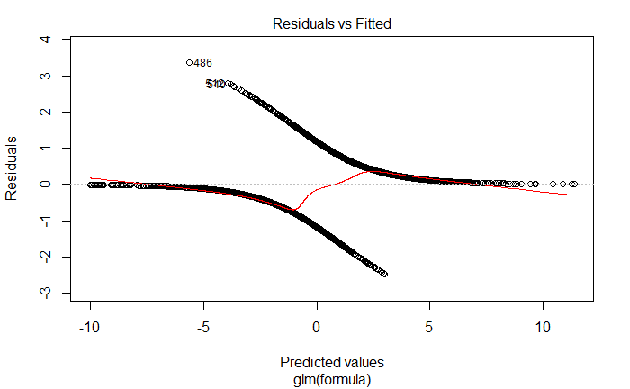

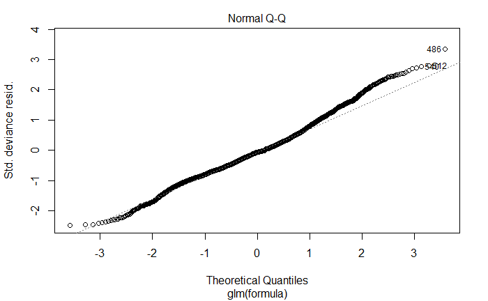

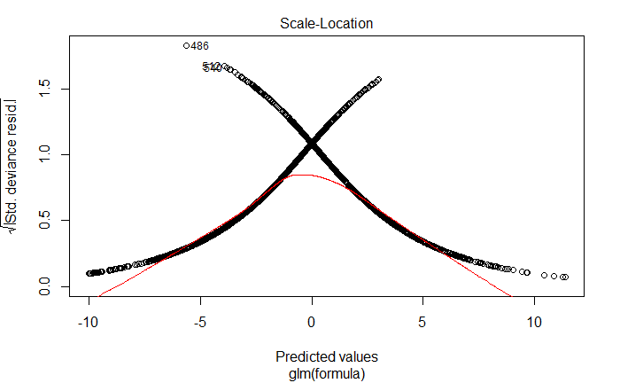

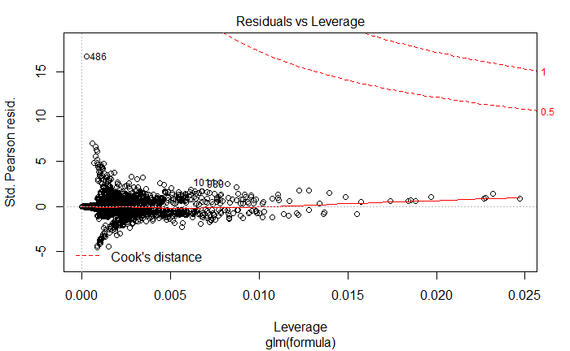

```
[1] "############# Test Confusion Matrix ##################"
   pred_class
       0    1
  0 1319  286
  1  181 1107
[1] "############# Train Accuracy ##################"
[1] 0.8385759
[1] "############# Train Recall ##################"
[1] 0.859472
[1] "############# Train Precision ##################"
[1] 0.7946877
[1] "############# Test Confusion matrix ##################"
   pred_class
      0   1
  0 461  87
  1  69 436
[1] "############# Test Accuracy ##################"
[1] 0.8518519
[1] "############# Train Recall ##################"
[1] 0.8633663
[1] "############# Train Precision ##################"
[1] 0.833652
```

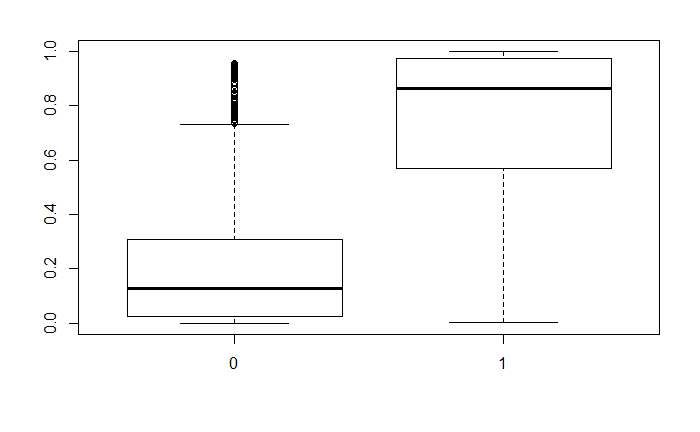

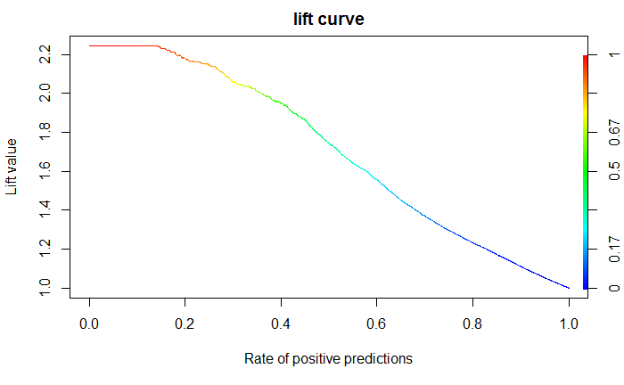

```
[1] "########## AUC ###############"
[1] 0.9200814
```

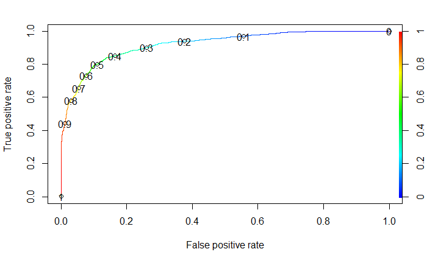

```r
result.logistic.full.data = logisticRegressionModel(train,test,fmla)
```

```r
print("########## Logistic result on full data ###############")
```

```
[1] "########## Logistic result on full data ###############"
```

```r
print ("#### Customer likely to opt service")
```

```
[1] "#### Customer likely to opt service"
```

```r
print(result.logistic.full.data)
```

| Unchurned.Data.Rev.Code |
| --- |
| 3 |
| 3 |
| 1 |
| 3 |
| 3 |
| 3 |
| 3 |
| 3 |
| 3 |
| 3 |

[output cut: 520 more lines]

```r
print("########## Logistic on Customer type1  data ###############")
```

```
[1] "########## Logistic on Customer type1  data ###############"
```

```
glm(formula = formula, family = binomial, data = train)
                                coef.est coef.se
(Intercept)                     127.00     8.36
lastCall                          0.00     0.00
Encoded.Area.Year.Quarter.Month  14.74     0.89
Encoded.last.Trans.Delays         4.91     0.96
Week.End.Timestamp                0.00     0.00
Masked.Customer.Id               -8.04     0.89
---
  n = 1617, k = 6
  residual deviance = 1210.3, null deviance = 2226.0 (difference = 1015.6)
```

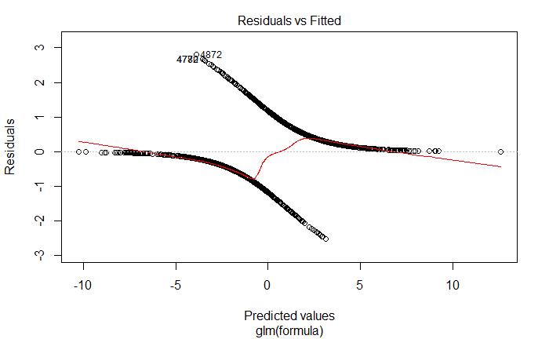

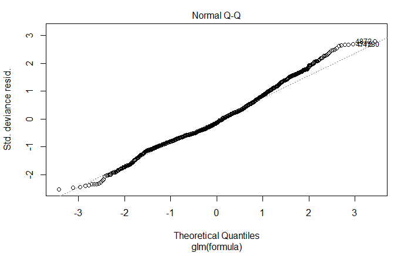

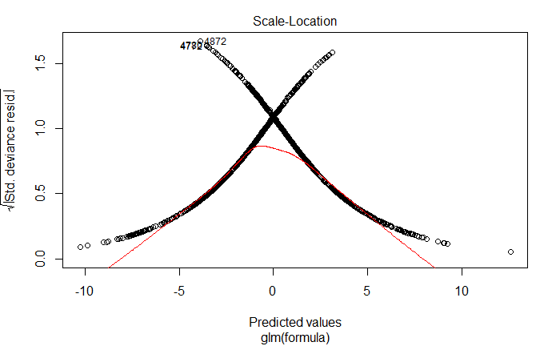

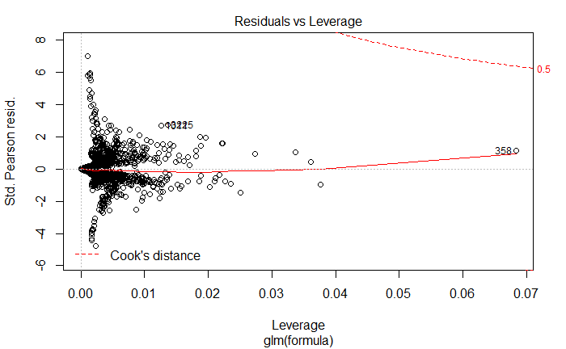

```
[1] "############# Test Confusion Matrix ##################"
   pred_class
      0   1
  0 723 165
  1 109 620
[1] "############# Train Accuracy ##################"
[1] 0.8305504
[1] "############# Train Recall ##################"
[1] 0.8504801
[1] "############# Train Precision ##################"
[1] 0.7898089
[1] "############# Test Confusion matrix ##################"
   pred_class
      0   1
  0 263  41
  1  55 237
[1] "############# Test Accuracy ##################"
[1] 0.8389262
[1] "############# Train Recall ##################"
[1] 0.8116438
[1] "############# Train Precision ##################"
[1] 0.852518
```

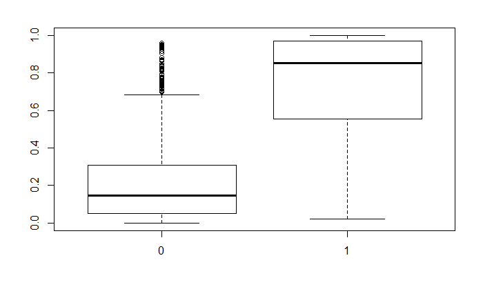

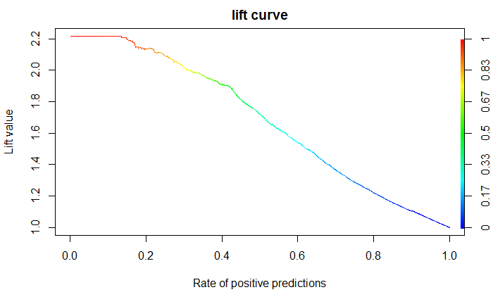

```
[1] "########## AUC ###############"
[1] 0.9100752
```

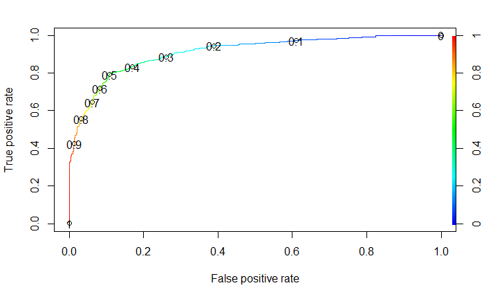

```r
result.logistic.customer.type1 = logisticRegressionModel(train = train1,test = test1,fmla)
```

```r
print("########## Logistic result on type1 data ###############")
```

```
[1] "########## Logistic result on type1 data ###############"
```

```r
print ("#### Customer likely to opt service")
```

```
[1] "#### Customer likely to opt service"
```

```r
print(result.logistic.customer.type1)
```

| Unchurned.Data.Rev.Code |
| --- |
| 3 |
| 3 |
| 3 |
| 1 |
| 3 |
| 3 |
| 3 |
| 3 |
| 3 |
| 3 |

[output cut: 308 more lines]

```r
print("########## Logistic on Customer type2  data ###############")
```

```
[1] "########## Logistic on Customer type2  data ###############"
```

```
glm(formula = formula, family = binomial, data = train)
                                coef.est coef.se
(Intercept)                     109.73    15.88
lastCall                          0.00     0.00
Encoded.Area.Year.Quarter.Month  11.60     1.62
Encoded.last.Trans.Delays         5.69     1.28
Week.End.Timestamp                0.00     0.00
Masked.Customer.Id               -5.74     1.67
---
  n = 419, k = 6
  residual deviance = 298.1, null deviance = 580.8 (difference = 282.6)
```

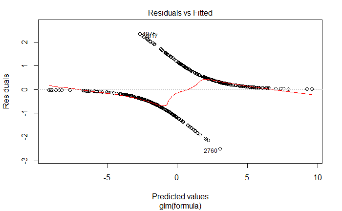

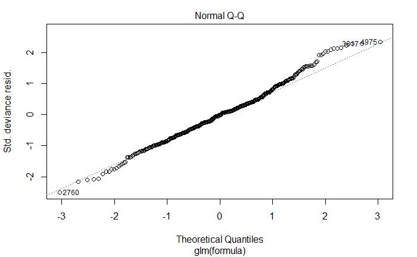

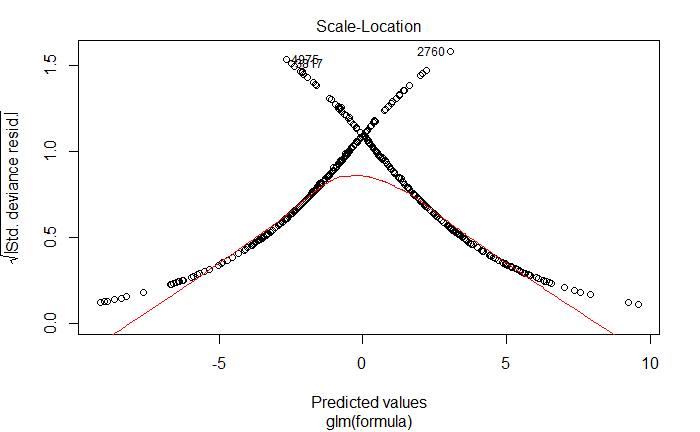

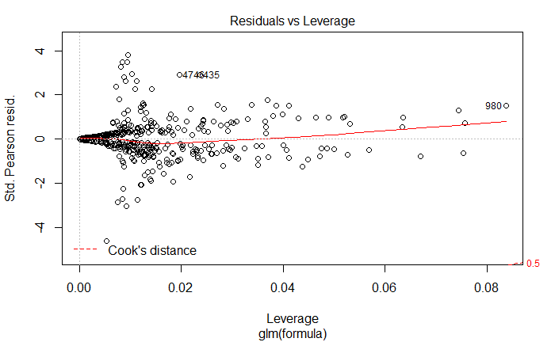

```
[1] "############# Test Confusion Matrix ##################"
   pred_class
      0   1
  0 166  46
  1  27 180
[1] "############# Train Accuracy ##################"
[1] 0.8257757
[1] "############# Train Recall ##################"
[1] 0.8695652
[1] "############# Train Precision ##################"
[1] 0.7964602
[1] "############# Test Confusion matrix ##################"
   pred_class
     0  1
  0 72 16
  1  3 61
[1] "############# Test Accuracy ##################"
[1] 0.875
[1] "############# Train Recall ##################"
[1] 0.953125
[1] "############# Train Precision ##################"
[1] 0.7922078
```

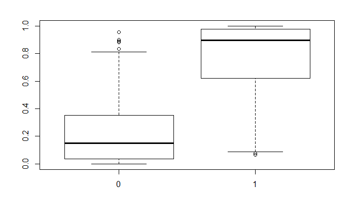

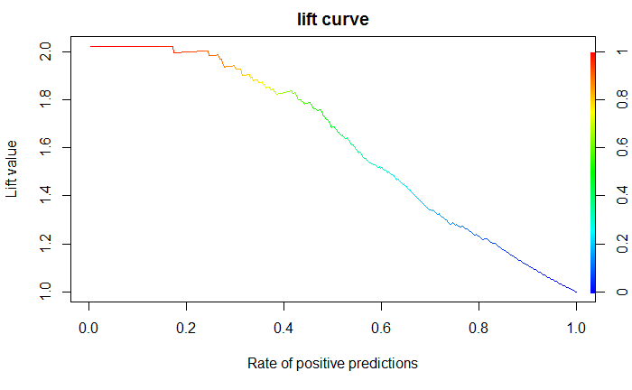

```
[1] "########## AUC ###############"
[1] 0.9188315
```

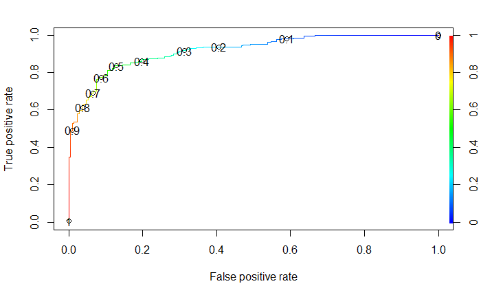

```r
result.logistic.customer.type2 = logisticRegressionModel(train = train2,test = test2,fmla)
```

```r
print("########## Logistic result on type2 data ###############")
```

```
[1] "########## Logistic result on type2 data ###############"
```

```r
print ("#### Customer likely to opt service")
```

```
[1] "#### Customer likely to opt service"
```

```r
print(result.logistic.customer.type2)
```

| Unchurned.Data.Rev.Code |
| --- |
| 3 |
| 3 |
| 3 |
| 1 |
| 1 |
| 3 |
| 1 |
| 1 |
| 3 |
| 1 |

[output cut: 65 more lines]

```r
print("########## Logistic on Customer type3  data ###############")
```

```
[1] "########## Logistic on Customer type3  data ###############"
```

```
glm(formula = formula, family = binomial, data = train)
                                coef.est coef.se
(Intercept)                     91.53    10.72
lastCall                         0.00     0.00
Encoded.Area.Year.Quarter.Month 12.31     1.34
Encoded.last.Trans.Delays        6.94     0.81
Week.End.Timestamp               0.00     0.00
Masked.Customer.Id              -7.75     1.49
---
  n = 856, k = 6
  residual deviance = 502.7, null deviance = 1159.5 (difference = 656.8)
```

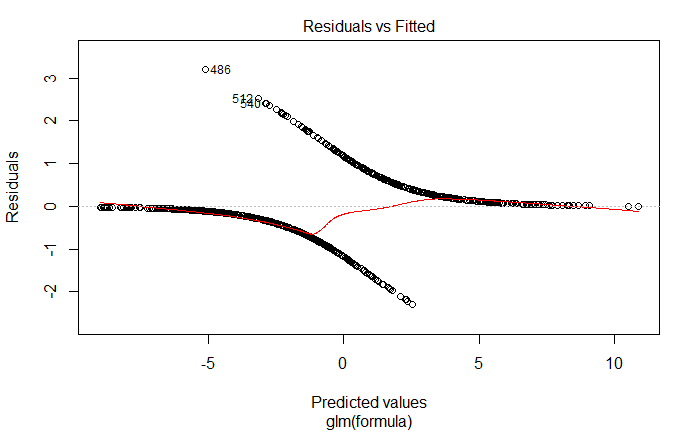

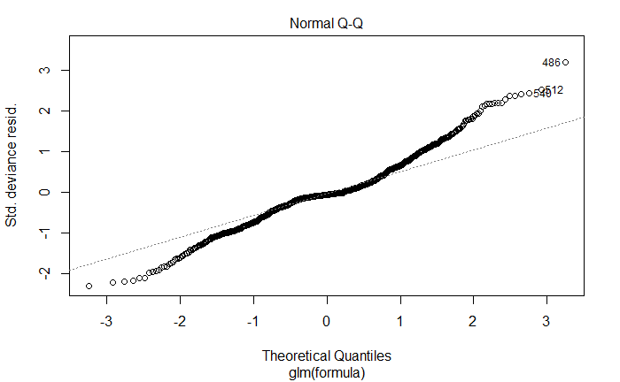

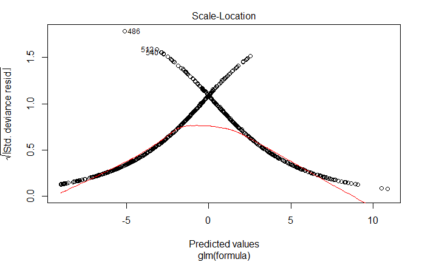

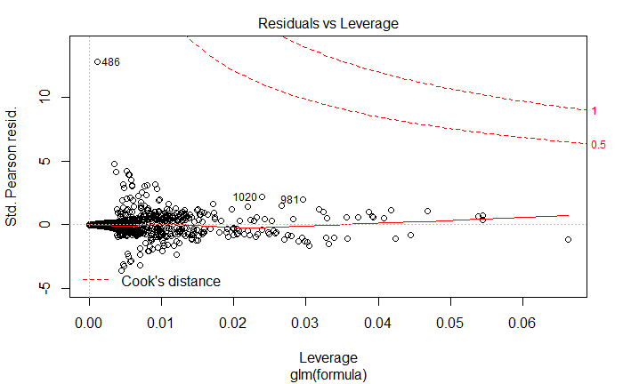

```
[1] "############# Test Confusion Matrix ##################"
   pred_class
      0   1
  0 423  81
  1  39 313
[1] "############# Train Accuracy ##################"
[1] 0.8598131
[1] "############# Train Recall ##################"
[1] 0.8892045
[1] "############# Train Precision ##################"
[1] 0.7944162
[1] "############# Test Confusion matrix ##################"
   pred_class
      0   1
  0 136  21
  1  15 134
[1] "############# Test Accuracy ##################"
[1] 0.8823529
[1] "############# Train Recall ##################"
[1] 0.8993289
[1] "############# Train Precision ##################"
[1] 0.8645161
```

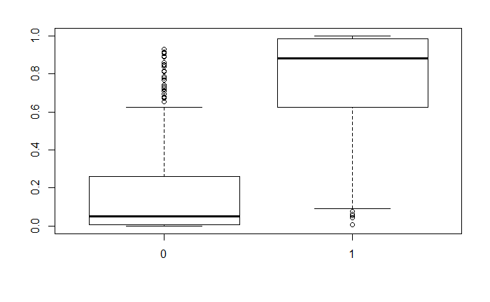

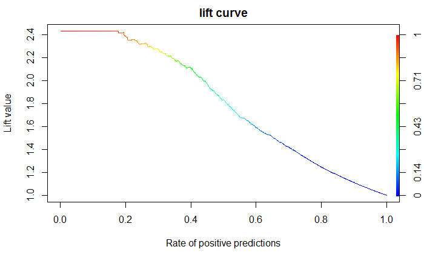

```
[1] "########## AUC ###############"
[1] 0.9440893
```

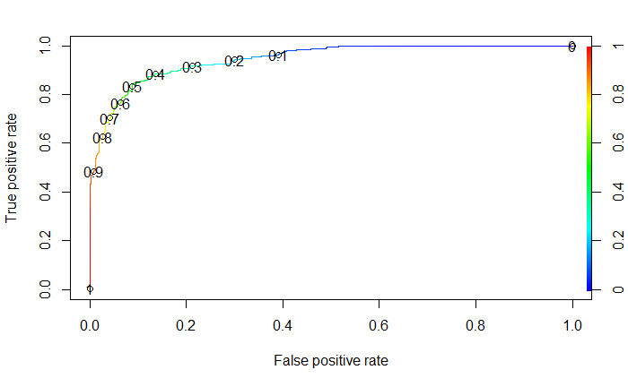

```r
result.logistic.customer.type3 = logisticRegressionModel(train = train3,test = test3,fmla)
```

```r
print("########## Logistic result on type3 data ###############")
```

```
[1] "########## Logistic result on type3 data ###############"
```

```r
print ("#### Customer likely to opt service")
```

```
[1] "#### Customer likely to opt service"
```

```r
print(result.logistic.customer.type3)
```

| Unchurned.Data.Rev.Code |
| --- |
| 3 |
| 3 |
| 1 |
| 3 |
| 3 |
| 3 |
| 1 |
| 1 |
| 3 |
| 1 |

[output cut: 141 more lines]

```r
print("########## End of Logistic Regression ###############")
```

```
[1] "########## End of Logistic Regression ###############"
```

Random Forest

```r
randomForestModel <- function(train, test, attr){
train_Data = train[,attr]
test_Data = test[,attr]
table(train_Data$churn)
table(test_Data$churn)
train_Data$churn = as.factor(train_Data$churn)
test_Data$churn = as.factor(test_Data$churn)
# Build the classification model using randomForest
model = randomForest(churn ~ ., data=train_Data,
                      keep.forest=TRUE, ntree=5)
# Print and understand the model
print(model)
# Important attributes
model$importance
round(importance(model), 2)
# Extract and store important variables obtained from the random forest model
rf_Imp_Attr = data.frame(model$importance)
rf_Imp_Attr = data.frame(row.names(rf_Imp_Attr),rf_Imp_Attr[,1])
colnames(rf_Imp_Attr) = c('Attributes', 'Importance')
rf_Imp_Attr = rf_Imp_Attr[order(rf_Imp_Attr$Importance, decreasing = TRUE),]
# plot (directly prints the important attributes)
varImpPlot(model)
# Predict on Train data
pred_Train = predict(model, train_Data[,setdiff(names(train_Data),"churn")],
                     type="response", norm.votes=TRUE)
# Build confusion matrix and find accuracy
cm_Train = table("actual"= train_Data$churn, "predicted" = pred_Train);
accu_Train= sum(diag(cm_Train))/sum(cm_Train)
rm(pred_Train, cm_Train)
# Predicton Test Data
pred_Test = predict(model, test_Data[,setdiff(names(test_Data),"churn")],
                    type="response", norm.votes=TRUE)
# Build confusion matrix and find accuracy
cm_Test = table("actual"= test_Data$churn, "predicted" = pred_Test);
accu_Test= sum(diag(cm_Test))/sum(cm_Test)
print("Train Accuracy")
print(accu_Train)
print("Test Accuracy")
print(accu_Test)
test$pred = pred_Test
Unchurned.Data =  test[with(test, pred == "0" ),]

result = data.frame(Unchurned.Data$Rev.Code)
rm(pred_Test, cm_Test)
return (result)
}
attr = c("Encoded.Area.Year.Quarter.Month",
         "Encoded.last.Trans.Delays","lastCall" ,"Masked.Customer.Id","Week.End.Timestamp"
         ,"Schedule.Date.Time.timestamp","churn")
setdiff(attr,names(train))
```

```
character(0)
```

```r
print("########## Random Forest on full data ###############")
```

```
[1] "########## Random Forest on full data ###############"
```

```
Call:
 randomForest(formula = churn ~ ., data = train_Data, keep.forest = TRUE,      ntree = 5)
               Type of random forest: classification
                     Number of trees: 5
No. of variables tried at each split: 2

        OOB estimate of  error rate: 9.97%
Confusion matrix:
     0    1 class.error
0 1300  114  0.08062235
1  142 1011  0.12315698
[1] "Train Accuracy"
[1] 0.9868648
[1] "Test Accuracy"
[1] 0.9135802
```

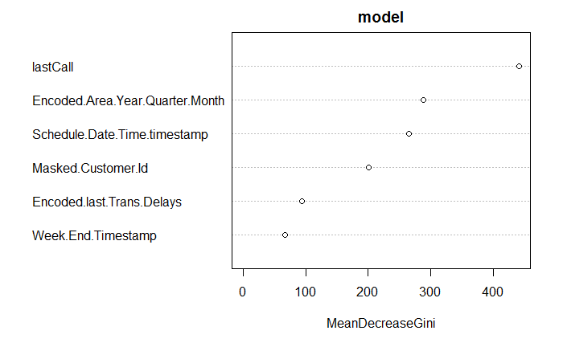

```r
result.random.full.data = randomForestModel(train,test,attr)
```

```r
print("########## Random Forest result on full data ###############")
```

```
[1] "########## Random Forest result on full data ###############"
```

```r
print ("#### Customer likely to opt service")
```

```
[1] "#### Customer likely to opt service"
```

```r
print(result.random.full.data)
```

| Unchurned.Data.Rev.Code |
| --- |
| 3 |
| 3 |
| 1 |
| 1 |
| 3 |
| 3 |
| 3 |
| 3 |
| 3 |
| 3 |

[output cut: 523 more lines]

```r
print("########## Random Forest on type1  data ###############")
```

```
[1] "########## Random Forest on type1  data ###############"
```

```
Call:
 randomForest(formula = churn ~ ., data = train_Data, keep.forest = TRUE,      ntree = 5)
               Type of random forest: classification
                     Number of trees: 5
No. of variables tried at each split: 2

        OOB estimate of  error rate: 11.08%
Confusion matrix:
    0   1 class.error
0 733  75  0.09282178
1  88 575  0.13273002
[1] "Train Accuracy"
[1] 0.9888683
[1] "Test Accuracy"
[1] 0.9328859
```

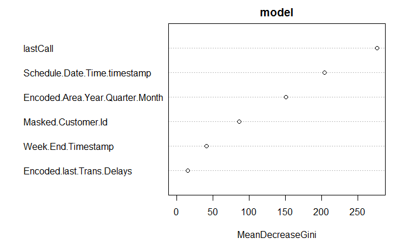

```r
result.random.customer.type1 = randomForestModel(train = train1,test = test1,attr)
```

```r
print("########## Random Forest result on Customer on type1 data ###############")
```

```
[1] "########## Random Forest result on Customer on type1 data ###############"
```

```r
print ("#### Customer likely to opt service")
```

```
[1] "#### Customer likely to opt service"
```

```r
print(result.random.customer.type1)
```

| Unchurned.Data.Rev.Code |
| --- |
| 1 |
| 3 |
| 3 |
| 3 |
| 3 |
| 1 |
| 3 |
| 3 |
| 3 |
| 3 |

[output cut: 292 more lines]

```r
print("########## Random Forest on Customer type2  data ###############")
```

```
[1] "########## Random Forest on Customer type2  data ###############"
```

```
Call:
 randomForest(formula = churn ~ ., data = train_Data, keep.forest = TRUE,      ntree = 5)
               Type of random forest: classification
                     Number of trees: 5
No. of variables tried at each split: 2

        OOB estimate of  error rate: 17.11%
Confusion matrix:
    0   1 class.error
0 158  30   0.1595745
1  34 152   0.1827957
[1] "Train Accuracy"
[1] 0.9880668
[1] "Test Accuracy"
[1] 0.8421053
```

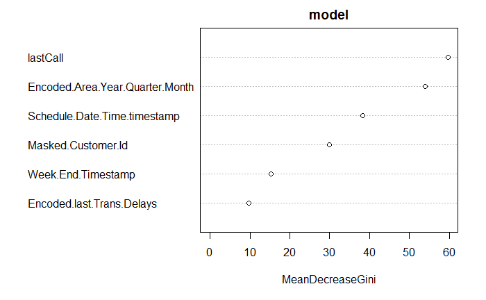

```r
result.random.customer.type2 = randomForestModel(train = train2,test = test2,attr)
```

```r
print("########## Random Forest on on type2 data ###############")
```

```
[1] "########## Random Forest on on type2 data ###############"
```

```r
print ("#### Customer likely to opt service")
```

```
[1] "#### Customer likely to opt service"
```

```r
print(result.random.customer.type2)
```

| Unchurned.Data.Rev.Code |
| --- |
| 1 |
| 3 |
| 3 |
| 3 |
| 3 |
| 3 |
| 1 |
| 3 |
| 1 |
| 1 |

[output cut: 68 more lines]

```r
print("########## Random Forest on Customer type3  data ###############")
```

```
[1] "########## Random Forest on Customer type3  data ###############"
```

```
Call:
 randomForest(formula = churn ~ ., data = train_Data, keep.forest = TRUE,      ntree = 5)
               Type of random forest: classification
                     Number of trees: 5
No. of variables tried at each split: 2

        OOB estimate of  error rate: 16.69%
Confusion matrix:
    0   1 class.error
0 397  54   0.1197339
1  74 242   0.2341772
[1] "Train Accuracy"
[1] 0.9836449
[1] "Test Accuracy"
[1] 0.9019608
```

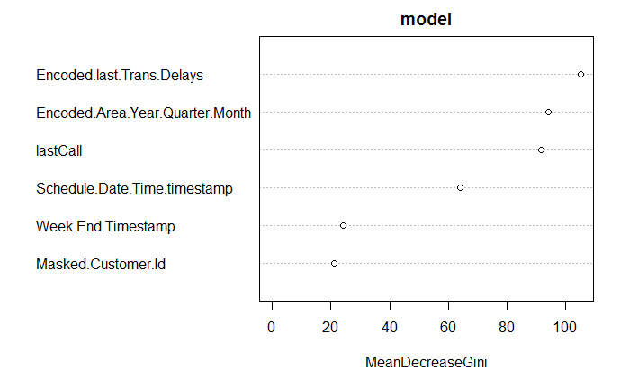

```r
result.random.customer.type3 = randomForestModel(train = train3,test = test3,attr)
```